# Efficacité du parc immobilier français — document de preuve

Premiers constats : parc et ménages (1982-2025), vacance structurelle du parc privé (2020-2026), croisements emploi et coût par zone d’emploi, taux d’effort, tension, état du bâti, coût de remobilisation, foncier immobilisé, rotation résidentielle, mobilité du parc social et des personnes, coût de transaction — chiffres révisés par les revues contradictoires du 2026-08-07 et du 2026-08-09 ; puis les mécanismes institutionnels comparés et la proposition P-01 (session 7, 2026-09-18)

Date de publication

18 septembre 2026

Ce document est le **document de preuve** des premiers résultats de la recherche « Efficacité du parc immobilier français » (projet Métabolisme). Il est **exécutable** : chaque chiffre affiché est recalculé à la volée par le code stabilisé du dépôt (`src/logement/`), à partir des fichiers sources figés (`data/raw/`, empreintes sha256 vérifiées), et confronté aux artefacts publiés (`data/processed/`). Les statuts épistémiques (S sources, D définitions, H hypothèses, O/T/R/I, V valeurs, C choix, L limites) sont ceux du graphe de preuves `evidence/claims.yaml`.

**initialisation : accès au dépôt et aux registres**

```python
import json
from pathlib import Path

import matplotlib.pyplot as plt
import matplotlib.ticker as mticker
import pandas as pd
import yaml

from logement.config import project_root
from logement.core import lovac, parc
from logement.shell import build

ROOT = project_root()
C1, C2, C3, C4 = "#2a78d6", "#eb6834", "#1baf7a", "#eda100"

def load_yaml(rel: str) -> list[dict]:
    return yaml.safe_load((ROOT / rel).read_text(encoding="utf-8")) or []

sources = load_yaml("sources/sources.yaml")
definitions = load_yaml("sources/definitions.yaml")
hypotheses = load_yaml("sources/hypotheses.yaml")
```

## 1. Question étudiée

> Dans quelle mesure le parc immobilier français permet-il de loger correctement la population, dans les territoires où elle souhaite ou a besoin de vivre, à un coût soutenable et avec une mobilité suffisante, en mobilisant mieux les capacités qui ne sont pas actuellement consacrées à une résidence principale ?

Ce premier document couvre deux sous-questions empiriques du cadrage (`INTRO.md` §15) :

1. Le nombre de logements augmente-t-il au même rythme que les ménages ? (**R-01**)
2. Où se trouve la vacance durable, et quelle part semble structurelle ? (**R-02**)

**Axiome normatif (V-01)** : une résidence principale occupée est pleinement utilisée — elle n’est jamais comptée comme capacité disponible ni comme inefficience. Le champ d’analyse est la capacité *hors* résidence principale.

## 2. Définitions

Les définitions sont citées verbatim depuis leur source et versionnées dans `sources/definitions.yaml` ; les limites de chacune y sont documentées.

**tableau des définitions depuis le registre**

```python
defs = pd.DataFrame(
    [
        {
            "id": d["id"],
            "terme": d["term"],
            "source": d["source"],
            "mise à jour": d.get("last_updated", "—"),
        }
        for d in definitions
    ]
)
defs.style.hide(axis="index")
```

| id | terme | source | mise à jour |
| --- | --- | --- | --- |
| D-01 | logement | S-04 | 2025-12-22 |
| D-02 | résidence principale | S-04 | 2020-05-14 |
| D-03 | logement vacant | S-04 | 2021-01-25 |
| D-04 | résidence secondaire | S-04 | 2021-01-14 |
| D-05 | ménage (recensement de la population) | S-04 | 2026-04-02 |
| D-06 | ménage (au sens de ménage-logement) | S-04 | 2026-07-07 |
| D-07 | zone d'emploi | S-04 | 2025-05-27 |
| D-08 | bassin de vie | S-04 | 2016-10-12 |
| D-09 | taux d'effort (occupation de la résidence principale) | S-04 | 2026-07-31 |
| D-10 | vacance structurelle (parc privé, LOVAC) | S-05 | — |
| D-11 | vacance frictionnelle (parc privé, LOVAC) | S-05 | — |
| D-12 | habitat indigne | S-08 | 2009-03-25 |
| D-13 | passoire thermique (logements classés F et G) | S-08 | 2021-08-25 |
| D-14 | zone tendue (champ de la taxe annuelle sur les logements vacants, art. 232 CGI) | S-08 | 2023-01-01 |
| D-15 | vacance de fluidité (taux de vacance nécessaire à la rotation du parc) | S-14 | 2020-07-01 |
| D-16 | ancienneté d'emménagement dans le logement (recensement de la population) | S-04 | 2026-08-06 |
| D-17 | taux de mobilité du parc locatif social (RPLS) | S-28 | 2022-01-01 |
| D-18 | migration résidentielle annuelle (recensement, fichier MIGCOM) | S-29 | 2026-08-08 |
| D-19 | droits de mutation à titre onéreux (DMTO) | S-43 | 2018-11-08 |
| D-20 | loyer net et structure d'exploitation d'un bailleur social (macro-organisme) | S-40 | 2025-09-11 |
| D-21 | bail à réhabilitation (CCH, art. L252-1 à L252-6) | S-46 | 2025-06-23 |
| D-22 | expropriation pour cause d'utilité publique et indemnité principale (valeur vénale) | S-45 | 2025-11-28 |
| D-23 | loyer d'équilibre (construction de l'étude) | S-40 | 2026-09-18 |
| D-24 | logement commencé (mise en chantier) et date de prise en compte (Sitadel) | S-55 | 2026-03-31 |

Deux points structurants :

- **D-03 (logement vacant, INSEE)** agrège vacance frictionnelle et durable ; la distinction décisive pour l’étude vient de LOVAC : **D-10** (vacance structurelle, plus de 2 ans) et **D-11** (frictionnelle).
- **D-05 (ménage, recensement)** a été remplacé le 31/08/2025 par **D-06** (ménage-logement) — les séries longues utilisées reposent sur l’ancien concept.

## 3. Sources

Chaque source est enregistrée avec ses dates, périmètres, licence et l’empreinte sha256 de ses fichiers figés (`uv run logement validate` vérifie les empreintes à chaque exécution).

**tableau des sources depuis le registre**

```python
def n_files(s: dict) -> int:
    if s.get("local_file"):
        return 1
    return len(s.get("files", []))

srcs = pd.DataFrame(
    [
        {
            "id": s["id"],
            "éditeur": s["publisher"],
            "titre": s["title"][:80],
            "publication": s.get("publication_date") or "collection vivante",
            "récupérée le": s["retrieved_at"],
            "fichiers figés": n_files(s),
        }
        for s in sources
    ]
)
srcs.style.hide(axis="index")
```

| id | éditeur | titre | publication | récupérée le | fichiers figés |
| --- | --- | --- | --- | --- | --- |
| S-01 | INSEE | Parc de logements au 1er janvier 2025 — données des figures (Insee Focus n° 359) | 2025-09-17 | 2026-08-03 | 1 |
| S-02 | INSEE | Répartition du parc selon la catégorie de logement et le type d'habitat (chiffre | 2025-09-17 | 2026-08-03 | 1 |
| S-03 | INSEE | Ménages et familles en 2022 et en séries longues — nombre de personnes par ménag | 2025-09-03 | 2026-08-03 | 1 |
| S-04 | INSEE | Définitions — métadonnées statistiques (collection en ligne) | collection vivante | 2026-08-03 | 0 |
| S-05 | Ministère de la Transition écologique (DGALN / Cerema DataFoncier) | LOVAC open data — logements vacants du parc privé par commune, département, régi | 2026-06-25 | 2026-08-03 | 4 |
| S-06 | INSEE | Table d'appartenance géographique des communes au 1er janvier 2026 | 2026-03-19 | 2026-08-03 | 1 |
| S-07 | INSEE | Estimation d'emploi par zone d'emploi et secteur d'activité de 1998 à 2018 | 2021-05-11 | 2026-08-03 | 1 |
| S-08 | Légifrance (DILA) | Textes législatifs et réglementaires consolidés (collection en ligne) | collection vivante | 2026-08-03 | 0 |
| S-09 | ANIL / DHUP (Ministère de la Transition écologique) | Carte des loyers — indicateurs de loyers d'annonce par commune en 2025 | 2025-12-11 | 2026-08-03 | 2 |
| S-10 | INSEE | Filosofi 2021 — principaux indicateurs sur les revenus et la pauvreté (géographi | 2024-01-29 | 2026-08-03 | 1 |
| S-11 | INSEE | Recensement 2022 — chiffres clés logement, base communale (base-cc-logement-2022 | 2025-06-26 | 2026-08-03 | 1 |
| S-12 | SDES (Ministère de la Transition écologique) | Les conditions de logement des ménages résidant en France en 2020 — Datalab esse | 2022-12-01 | 2026-08-05 | 1 |
| S-13 | Ministère de la Transition écologique (Observatoire habitat) | Liste des communes selon le zonage TLV (taxe sur les logements vacants), version | 2025-12-30 | 2026-08-05 | 2 |
| S-14 | DREAL Pays de la Loire (collection Analyses et connaissance) | Lutter contre la vacance des logements — capitalisation des Programmes Locaux de | 2020-07-01 | 2026-08-05 | 1 |
| S-15 | Observatoire de l'habitat de la Communauté Urbaine d'Alençon (réseau des observatoires locaux des loyers) | La vacance — données de cadrage et chiffres clés, 2025 | 2025-01-01 | 2026-08-05 | 1 |
| S-16 | ADEME (observatoire DPE) | DPE logements existants (depuis juillet 2021) — extrait agrégé commune × étiquet | 2026-07-29 | 2026-08-05 | 1 |
| S-17 | Enertech (pour le compte de l'ADEME) | Analyse des coûts de la rénovation énergétique des logements en France | 2016-07-01 | 2026-08-05 | 1 |
| S-18 | Banque des Territoires (Caisse des Dépôts) | Éclairages n°33 — Le prix de revient des logements sociaux face à l'accumulation | 2024-12-01 | 2026-08-05 | 1 |
| S-19 | INSEE (BDM, série 011779962) | Indice des prix de l'entretien-amélioration des bâtiments — Résidentiel (IPEA, C | 2026-07-01 | 2026-08-05 | 1 |
| S-20 | Cerema (Cartofriches, pour le Ministère de la Transition écologique) | Sites référencés dans Cartofriches — inventaire national des friches, export du | 2026-06-15 | 2026-08-05 | 1 |
| S-21 | INSEE | Base du comparateur de territoires (dont superficie des communes et arrondisseme | 2026-07-22 | 2026-08-05 | 1 |
| S-22 | Cour des comptes | La lutte contre les logements vacants dans le parc privé — observations définiti | 2025-05-22 | 2026-08-07 | 1 |
| S-23 | SDES (Ministère de la Transition écologique — Boutchenik B., Mathieu B.) | Les déterminants de la vacance longue durée des logements détenus par les person | 2023-12-01 | 2026-08-07 | 1 |
| S-24 | Apur (Atelier parisien d'urbanisme) | Les logements inoccupés à Paris — état des lieux, mise en perspective historique | 2023-12-05 | 2026-08-07 | 1 |
| S-25 | Cerema (Juliette Maître — présentation au Réseau national des aménageurs) | Coût des friches — analyse des lauréats du Fonds Friches (23/11/2023) | 2023-11-23 | 2026-08-07 | 1 |
| S-26 | Cerema | Recyclage des friches — quels enseignements des centaines de projets soutenus pa | 2023-12-04 | 2026-08-07 | 1 |
| S-27 | INSEE | Recensement de la population — Logements et résidences principales en 2023 (expl | 2026-08-08 | 2026-08-08 | 1 |
| S-28 | SDES (Commissariat général au développement durable) | Répertoire du parc locatif social (RPLS) au 1er janvier 2025 — résultats par rég | 2026-01-20 | 2026-08-08 | 1 |
| S-29 | INSEE | Recensement de la population — fichier détail MIGCOM, migrations résidentielles | 2026-08-08 | 2026-08-08 | 2 |
| S-30 | DGFiP / Etalab (data.gouv.fr) | Demandes de valeurs foncières géolocalisées (DVF) — mutations 2025, France entiè | 2026-05-18 | 2026-08-08 | 1 |
| S-31 | DGFiP (impots.gouv.fr, espace notaires) | Droits d'enregistrement et taxe de publicité foncière — taux, abattements et réd | 2026-02-01 | 2026-08-08 | 1 |
| S-32 | Service-Public / DILA (Premier ministre) | Frais de notaire — qu'est-ce que c'est ? (fiche F17701, barème des émoluments pr | 2026-08-05 | 2026-08-08 | 1 |
| S-33 | INSEE | Insee Première n° 2073 — Moins de déménagements en dix ans, mais l'Ouest et le p | 2025-09-30 | 2026-08-09 | 2 |
| S-34 | ANCOLS | Quelle est la part du vieillissement des attributaires dans la baisse de la mobi | 2026-02-09 | 2026-08-09 | 1 |
| S-35 | DGFiP (impots.gouv.fr, espace notaires) | Droits d'enregistrement et taxe de publicité foncière — taux, abattements et réd | 2026-06-01 | 2026-08-09 | 1 |
| S-36 | Banque de France | Stat Info « Crédits aux particuliers — France » • Mai 2026 | 2026-07-08 | 2026-08-09 | 1 |
| S-37 | DGFiP (impots.gouv.fr) | J'achète un bien immobilier — qu'aurai-je à payer comme frais au notaire ? (cont | 2026-08-09 | 2026-08-09 | 1 |
| S-38 | INSEE | Estimation de la population au 1er janvier — séries par département, sexe et âge | 2026-01-13 | 2026-08-09 | 1 |
| S-39 | Observatoire des finances et de la gestion publique locales (OFGL, DGCL) | Rapport OFGL 2025 — fiches « Les finances des départements » (exercice 2024) | 2025-07-22 | 2026-09-18 | 1 |
| S-40 | Banque des Territoires (Caisse des Dépôts) | Perspectives — L'étude sur le logement social, édition 2025 (comptes 2023 des ba | 2025-09-11 | 2026-09-18 | 1 |
| S-41 | Banque des Territoires (Caisse des Dépôts) | Prêt Locatif à Usage Social (PLUS) — conditions financières (page produit) | collection vivante | 2026-09-18 | 1 |
| S-42 | Banque des Territoires (Caisse des Dépôts) | Livret A à 1,7 % — une évolution maîtrisée qui confirme l'attractivité des prêts | 2026-07-31 | 2026-09-18 | 1 |
| S-43 | INSEE — Économie et Statistique n° 500-501-502 (Bérard G. & Trannoy A., Aix-Marseille School of Economics) | L'impact de la hausse des droits de mutation immobiliers de 2014 sur le marché d | 2018-11-08 | 2026-09-18 | 1 |
| S-44 | OCDE (Centre de politique et d'administration fiscales) | La fiscalité immobilière dans les pays de l'OCDE — points clés (brochure) | 2022-11-09 | 2026-09-18 | 1 |
| S-45 | Service-Public.gouv.fr (DILA, Premier ministre) | Procédure d'expropriation (fiche F762) | 2025-11-28 | 2026-09-18 | 1 |
| S-46 | DREAL Occitanie (ministère de la Transition écologique) | Fiche 3.1 — Bail à réhabilitation (B.A.R) — boîte à outils « lutte contre la vac | 2025-06-23 | 2026-09-18 | 1 |
| S-47 | Observatoire des finances et de la gestion publique locales (OFGL, DGCL) | Pré-rapport OFGL 2026 — les finances des collectivités locales en 2025 (version | 2026-06-11 | 2026-09-18 | 1 |
| S-48 | Banque des Territoires (Caisse des Dépôts) | Prêt locatif aidé d'intégration (PLAI) — conditions financières (page produit) | collection vivante | 2026-09-18 | 1 |
| S-49 | Banque des Territoires (Caisse des Dépôts) | Prêt locatif social (PLS) — conditions financières (page produit) | collection vivante | 2026-09-18 | 1 |
| S-50 | Préfecture de l'Hérault (dossier de DUP, ZAC Enjalbert — pièce 8, estimation sommaire des dépenses) | Estimation sommaire des dépenses d'une DUP — calcul de l'indemnité de remploi (a | 2016-12-09 | 2026-09-18 | 1 |
| S-51 | Conseil des prélèvements obligatoires (CPO, Cour des comptes) | Pour une fiscalité du logement plus cohérente (rapport, 18 décembre 2023) | 2023-12-18 | 2026-09-18 | 1 |
| S-52 | Service-Public.gouv.fr (DILA, Premier ministre) | Une taxe unique pour les logements vacants à partir de 2027 (actualité A18896) | 2026-09-02 | 2026-09-18 | 1 |
| S-53 | DGCL (Département des études et des statistiques locales) — Bulletin d'information statistique n° 190 | Les droits de mutation à titre onéreux des départements en 2023 (BIS n° 190, nov | 2024-11-01 | 2026-09-18 | 1 |
| S-55 | SDES (ministère de la Transition écologique) | La base de données Sitadel — méthodologie (page de référence, mise à jour du 31/ | 2026-03-31 | 2026-09-18 | 1 |
| S-54 | SDES (ministère de la Transition écologique) — via data.gouv.fr | Sit@del2 — logements autorisés et commencés, séries mensuelles communales en dat | 2026-09-05 | 2026-09-18 | 1 |
| S-56 | SDES (ministère de la Transition écologique) — catalogue DiDo | Sit@del2 — logements autorisés et commencés, données annuelles communales en dat | 2026-09-04 | 2026-09-18 | 1 |
| S-57 | SDES (ministère de la Transition écologique) — catalogue DiDo | Sit@del2 — logements autorisés et commencés, données mensuelles nationales estim | 2026-08-28 | 2026-09-18 | 1 |
| S-58 | SDES (ministère de la Transition écologique) | Présentation de la base nationale en open data des autorisations d'urbanisme (ex | 2021-06-01 | 2026-09-18 | 1 |
| S-59 | INSEE | Code officiel géographique au 1er janvier 2026 — ensemble des fichiers (dont mou | 2026-02-13 | 2026-09-18 | 1 |
| S-60 | SDES (ministère de la Transition écologique) — collection Études | Besoins en logements à horizon 2030, 2040 et 2050 (B. Boutchenik, G. Rateau, jui | 2025-06-11 | 2026-09-18 | 1 |


## 5. Hypothèses

**registre des hypothèses**

```python
hyp = pd.DataFrame(
    [
        {
            "id": h["id"],
            "nom": h["name"],
            "valeur centrale": h["central_value"],
            "plage plausible": str(h["plausible_range"]),
            "unité": h["unit"],
            "confiance": h["confidence"],
        }
        for h in hypotheses
    ]
)
hyp.style.hide(axis="index")
```

| id | nom | valeur centrale | plage plausible | unité | confiance |
| --- | --- | --- | --- | --- | --- |
| H-06 | structural_vacancy_threshold_years | 2.000000 | [1.0, 3.0] | years | medium |
| H-07 | relocation_surface_per_person_m2 | 35.000000 | [35.0, 51.2] | m2_per_person | low |
| H-08 | fluidity_vacancy_threshold_pct | 6.000000 | [5.0, 7.0] | pct_of_total_stock | low |
| H-09 | renovation_cost_maison_eur_ht_per_m2_2016 | 406.000000 | [348.0, 496.0] | eur_ht_2016_per_m2 | medium |
| H-10 | renovation_cost_collectif_eur_ht_per_m2_2016 | 250.000000 | [200.0, 300.0] | eur_ht_2016_per_m2 | medium |
| H-11 | haussmann_reference_density_dwellings_per_ha | 147.200000 | [70.6, 225.7] | dwellings_per_ha | medium |
| H-12 | lovac_structural_existence_rate | 0.750000 | [0.6, 0.9] | fraction | low |
| H-13 | transfer_tax_rate_pct | 6.320000 | [5.09, 6.32] | pct_of_price | medium |
| H-14 | incentive_channel_exit_rate_pct_per_year | 0.750000 | [0.25, 2.5] | pct_of_effective_stock_per_year | low |
| H-15 | vacant_acquisition_price_discount_factor | 1.000000 | [0.5, 1.0] | factor_on_median_price | low |
| H-16 | operator_borrowing_rate_pct | 2.300000 | [1.5, 3.6] | pct_per_year | medium |
| H-17 | operator_amortisation_years | 40.000000 | [30.0, 50.0] | years | medium |
| H-18 | operator_operating_cost_eur_per_dwelling_per_year | 2652.000000 | [2093.0, 3978.0] | eur_per_dwelling_per_year | low |
| H-19 | lease_amortisation_years | 30.000000 | [12.0, 40.0] | years | medium |
| H-20 | expropriation_reemployment_indemnity_pct | 10.000000 | [0.0, 10.5] | pct_of_acquisition_price | medium |
| H-21 | sitadel_communal_undercount_factor | 1.155000 | [1.122, 1.235] | factor | medium |

**H-06** — le seuil de 2 ans qui sépare vacance frictionnelle et structurelle est une convention administrative (choix **C-01**), pas un fait : il est paramétré, et sa plage plausible (1-3 ans) devra être explorée dès que les fichiers LOVAC détaillés (ancienneté fine) seront acquis.

Deux changements tracés par la revue contradictoire (2026-08-07) : **H-07** (surface de relocation) a été **recentrée** sur les emménagés récents — 35 m²/personne (tranche 30-39 ans, S-12), l’ancien centre 51,2 (parc en place) devenant la borne haute « relocation au standard du parc » ; et **H-12** (taux d’existence du gisement LOVAC, 0,75, plage 0,6-0,9) a été **créée** : la Cour des comptes (S-22) établit qu’environ 25 % des logements réputés vacants dans LOVAC ne le sont pas ou plus — H-12 est propagée des DEUX côtés du test de tension (gisement effectif ET vacance disponible, choix C-06).

## 6. Résultats

### Vérification de reproduction

Avant d’afficher quoi que ce soit, on vérifie que les artefacts publiés sont exactement ce que la chaîne recalcule depuis les fichiers figés :

```python
r01 = build.build_parc_menages(ROOT)
r02 = build.build_vacance_structurelle(ROOT)
r03 = build.build_vacance_emploi(ROOT)
r04 = build.build_cout_residentiel(ROOT)
r05 = build.build_residences_secondaires(ROOT)
r06 = build.build_taux_effort(ROOT)
r07 = build.build_tension(ROOT)
r08 = build.build_etat_bati(ROOT)
r09 = build.build_cout_remobilisation(ROOT)
r10 = build.build_foncier(ROOT)
r11 = build.build_mobilite(ROOT)
r12 = build.build_social(ROOT)
r13 = build.build_migrations(ROOT)
r14 = build.build_transaction(ROOT)
r15 = build.build_institution(ROOT)  # R-15..R-17 partagent un artefact
r18 = build.build_flux(ROOT)
for name, computed, output in [
    ("R-01", r01, build.OUTPUT), ("R-02", r02, build.LOVAC_OUTPUT),
    ("R-03", r03, build.ZE_OUTPUT), ("R-04", r04, build.COUT_OUTPUT),
    ("R-05", r05, build.RS_OUTPUT), ("R-06", r06, build.EFFORT_OUTPUT),
    ("R-07", r07, build.TENSION_OUTPUT), ("R-08", r08, build.BATI_OUTPUT),
    ("R-09", r09, build.REMOB_OUTPUT), ("R-10", r10, build.FONCIER_OUTPUT),
    ("R-11", r11, build.MOBILITE_OUTPUT), ("R-12", r12, build.SOCIAL_OUTPUT),
    ("R-13", r13, build.MIGRATIONS_OUTPUT), ("R-14", r14, build.TRANSACTION_OUTPUT),
    ("R-15..R-17", r15, build.INSTITUTION_OUTPUT), ("R-18", r18, build.FLUX_OUTPUT),
]:
    committed = json.loads((ROOT / output).read_text(encoding="utf-8"))
    assert computed == committed, f"{name} diverge de l'artefact publié"
print("R-01..R-18 : artefacts publiés == recalcul depuis les sources figées ✔")
```

```
R-01..R-18 : artefacts publiés == recalcul depuis les sources figées ✔
```

### R-01 — Le parc suit les ménages, pas la population (1982-2025)

**séries indexées base 100 en 1982**

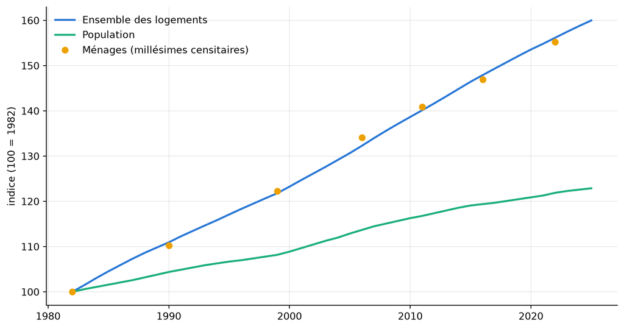

Logements, ménages, population — indice base 100 en 1982 (S-01, S-02, S-03 ; France hors Mayotte). Les millésimes ménages sont censitaires (points).

```python
raw = ROOT / "data" / "raw"
categories = parc.parse_eapl_categories(
    pd.read_excel(raw / build.S02_FILE, sheet_name="Données", header=3)
)
menages = parc.parse_menages_totals(
    pd.read_excel(raw / build.S03_FILE, sheet_name="France", header=None)
)
population_idx = parc.parse_population_index(
    pd.read_excel(raw / build.S01_FILE, sheet_name="Figure 2", header=2)
)
counts = categories.counts
dwellings_idx = parc.index_to_base(counts[parc.TOTAL], 1982)
menages_idx = parc.index_to_base(menages[menages.index >= 1982], 1982)

fig, ax = plt.subplots(figsize=(9, 4.8))
ax.plot(dwellings_idx.index, dwellings_idx, color=C1, lw=2, label="Ensemble des logements")
ax.plot(population_idx.index, population_idx, color=C3, lw=2, label="Population")
ax.plot(menages_idx.index, menages_idx, color=C4, lw=0, marker="o", ms=6,
        label="Ménages (millésimes censitaires)")
ax.set_ylabel("indice (100 = 1982)")
ax.grid(alpha=0.25)
ax.legend(frameon=False)
ax.spines[["top", "right"]].set_visible(False)
plt.tight_layout()
plt.show()
```

**chiffres clés R-01**

```python
idx = r01["indices_at_last_common_vintage"]
print(f"Indices {idx['year']} (base 100 en 1982) : logements {idx['dwellings']} · "
      f"ménages {idx['menages']} · population {idx['population']}")
vac = r01["vacancy"]
print(f"Logements vacants : {vac['count_thousands']['1982']} milliers (1982) → "
      f"{vac['count_thousands']['2025']} milliers (2025)")
print(f"Part de vacance : {vac['share_pct']['1982']} % (1982) → minimum "
      f"{vac['share_pct']['min']} % ({vac['share_pct']['min_year']}) → "
      f"{vac['share_pct']['2025']} % (2025)")
```

```
Indices 2022 (base 100 en 1982) : logements 156.2 · ménages 155.2 · population 121.9
Logements vacants : 1895 milliers (1982) → 2962 milliers (2025)
Part de vacance : 7.9 % (1982) → minimum 6.2 % (2005) → 7.7 % (2025)
```

Sur quarante ans, le parc croît au rythme des ménages (indices 2022 : 156,2 contre 155,2) et bien plus vite que la population (121,9) : la croissance du parc a accompagné la **décohabitation** (2,72 personnes par ménage en 1982, 2,15 en 2022). Le régime change vers 2005-2006 : avant, les ménages croissent plus vite que le parc et la vacance tombe à 6,2 % ; après, le parc croît plus vite et la vacance remonte à 7,7 % en 2025 (environ 3,0 millions de logements). La part des résidences secondaires est stable au niveau national (9,5 % → 9,8 %) : **la capacité hors résidence principale qui augmente depuis 2006 est de la vacance** (interprétation I-01).

### R-02 — La vacance structurelle du parc privé et sa géographie

**série nationale LOVAC et ruptures**

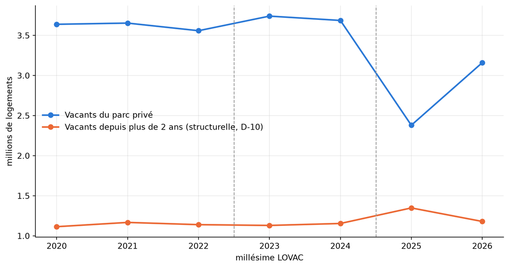

Vacance du parc privé, France, millésimes LOVAC 2020-2026 (millésime N = situation fiscale au 01/01/N-1). Les niveaux de vacance totale ne sont pas comparables au travers des ruptures 2023 et 2025 (L-04).

```python
france = lovac.parse_france(
    pd.read_csv(raw / build.LOVAC_FRANCE, sep=";", encoding="cp1252", dtype=str)
)
fig, ax = plt.subplots(figsize=(9, 4.8))
ax.plot(france.index, france["pp_vacant"] / 1e6, color=C1, lw=2, marker="o",
        label="Vacants du parc privé")
ax.plot(france.index, france["pp_vacant_plus_2ans"] / 1e6, color=C2, lw=2, marker="o",
        label="Vacants depuis plus de 2 ans (structurelle, D-10)")
for rupture in lovac.BREAK_MILLESIMES:
    ax.axvline(rupture - 0.5, color="#999999", ls="--", lw=1)
ax.set_ylabel("millions de logements")
ax.set_xlabel("millésime LOVAC")
ax.grid(alpha=0.25)
ax.legend(frameon=False)
ax.spines[["top", "right"]].set_visible(False)
plt.tight_layout()
plt.show()
```

**gradient départemental (millésime de référence C-03)**

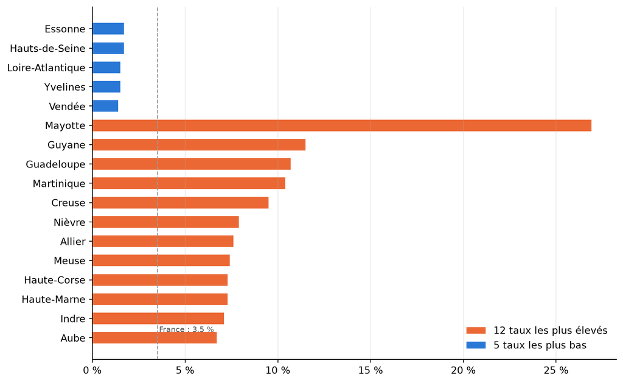

Taux de vacance structurelle du parc privé par département (> 2 ans, millésime 2024 — situation au 01/01/2023).

```python
top = pd.DataFrame(r02["departements"]["top"]).iloc[::-1]
bottom = pd.DataFrame(r02["departements"]["bottom"]).iloc[::-1]
national = r02["national"]["structural_rate_ref_pct"]
fig, ax = plt.subplots(figsize=(9, 5.6))
ax.barh(top["name"], top["rate_pct"], color=C2, height=0.6, label="12 taux les plus élevés")
ax.barh(bottom["name"], bottom["rate_pct"], color=C1, height=0.6, label="5 taux les plus bas")
ax.axvline(national, color="#999999", ls="--", lw=1)
ax.annotate(f"France : {national} %", (national + 0.1, 0.3), fontsize=8, color="#555555")
ax.xaxis.set_major_formatter(mticker.FormatStrFormatter("%.0f %%"))
ax.grid(alpha=0.25, axis="x")
ax.legend(frameon=False, loc="lower right")
ax.spines[["top", "right"]].set_visible(False)
plt.tight_layout()
plt.show()
```

**chiffres clés R-02**

```python
nat = r02["national"]
print(f"Vacance structurelle nationale (millésime de référence 24, dernier "
      f"pré-rupture, au 01/01/2023) : "
      f"{nat['structural_by_millesime']['2024']:,} logements".replace(",", " "))
print(f"Millésime 26 (au 01/01/2025, post-GMBI, source dégradée L-04) : "
      f"{nat['structural_by_millesime']['2026']:,} logements".replace(",", " "))
print(f"Taux structurel national (millésime {r02['reference_millesime']}) : "
      f"{nat['structural_rate_ref_pct']} % du parc privé")
com = r02["communes"]
print(f"Secrétisation communale : {com['n_masked_latest']:,}/{com['n_total']:,} communes "
      f"masquées au dernier millésime".replace(",", " "))
print(f"Communes visibles (mill. réf.) : {com['visible_ref']['n']:,} — "
      f"{com['visible_ref']['structural_share_pct']} % de la vacance structurelle nationale"
      .replace(",", " "))
print("Top volumes (PLM agrégées) :",
      ", ".join(f"{e['name']} {e['structural']:,}".replace(",", " ")
                for e in com["top_by_volume_ref"][:4]))
```

```
Vacance structurelle nationale (millésime de référence 24  dernier pré-rupture  au 01/01/2023) : 1 154 436 logements
Millésime 26 (au 01/01/2025  post-GMBI  source dégradée L-04) : 1 179 845 logements
Taux structurel national (millésime 2024) : 3.5 % du parc privé
Secrétisation communale : 17 767/34 912 communes masquées au dernier millésime
Communes visibles (mill. réf.) : 6 923 — 72.6 % de la vacance structurelle nationale
Top volumes (PLM agrégées) : Paris 32 091, Marseille 14 529, Nice 6 227, Toulouse 6 040
```

### R-03 — Vacance structurelle et dynamique de l’emploi (test de H-02)

**chiffres clés R-03**

```python
dec = r03["declining_ze"]
sp3 = r03["spearman_perimetres"]
print(f"{r03['n_ze']} zones d'emploi ; Spearman taux structurel × évolution "
      f"emploi 1998-2018 : {sp3['france_entiere']['rho']} "
      f"(IC 95 % {sp3['france_entiere']['ci95']}) ; métropole "
      f"{sp3['metropole']['rho']} (IC {sp3['metropole']['ci95']})")
print(f"ZE à emploi déclinant : {dec['n']} — {dec['structural_share_pct']} % de la "
      f"vacance structurelle VISIBLE pour {dec['private_stock_share_pct']} % du parc "
      f"privé ; taux médian {dec['median_rate_pct']} % contre "
      f"{r03['growing_ze_median_rate_pct']} % ailleurs")
sec3 = r03["secretisation"]
lo3, hi3 = sec3["declining_share_borne_pct"]
print(f"Borne de secrétisation : {sec3['n_communes_masquees']:,} communes masquées "
      f"(≤ {sec3['max_structurels_par_commune_masquee']} chacune) — part déclinante "
      f"entre {lo3} et {hi3} %, donc 'ZE croissantes' entre {round(100 - hi3, 1)} "
      f"et {round(100 - lo3, 1)} %".replace(",", " "))
print("Plus gros volumes en ZE dynamiques :",
      ", ".join(f"{e['name']} {e['structural']:,}".replace(",", " ")
                for e in r03["top_growing_by_volume"][:3]))
```

```
305 zones d'emploi ; Spearman taux structurel × évolution emploi 1998-2018 : -0.36 (IC 95 % [-0.46, -0.25]) ; métropole -0.47 (IC [-0.56, -0.37])
ZE à emploi déclinant : 63 — 15.1 % de la vacance structurelle VISIBLE pour 9.8 % du parc privé ; taux médian 4.5 % contre 2.9 % ailleurs
Borne de secrétisation : 26 927 communes masquées (≤ 10 chacune) — part déclinante entre 12.2 et 21.7 %  donc 'ZE croissantes' entre 78.3 et 87.8 %
Plus gros volumes en ZE dynamiques : Paris 69 803, Marseille 17 917, Région Pointoise 12 896
```

### R-04 — Pression du coût résidentiel et vacance (instruction de H-03)

**chiffres clés R-04**

```python
med = r04["median_vacancy_rate_pct"]
sp4 = r04["spearman_perimetres"]
print(f"{r04['n_ze']} ZE ; Spearman indice de coût × taux structurel : "
      f"{sp4['france_entiere']['rho']} (IC 95 % {sp4['france_entiere']['ci95']}) ; "
      f"métropole {sp4['metropole']['rho']} (IC {sp4['metropole']['ci95']})")
print(f"Taux de vacance médian : {med['expensive_half']} % (moitié des ZE au coût "
      f"relatif élevé) contre {med['cheap_half']} % (moitié bon marché)")
rng = r04["loyer_m2_range"]
print(f"Loyers pondérés : {rng['min']} / {rng['median']} / {rng['max']} €/m² "
      f"(min/médiane/max)")
print("Indices les plus élevés :",
      ", ".join(f"{e['name']} {e['indice_cout_pct']}" for e in r04["top_cost_index"][:4]))
```

```
297 ZE ; Spearman indice de coût × taux structurel : -0.43 (IC 95 % [-0.52, -0.33]) ; métropole -0.54 (IC [-0.62, -0.45])
Taux de vacance médian : 2.5 % (moitié des ZE au coût relatif élevé) contre 3.9 % (moitié bon marché)
Loyers pondérés : 8.0 / 11.2 / 27.2 €/m² (min/médiane/max)
Indices les plus élevés : Paris 1.28, L'Ouest 1.16, Menton 1.15, Roissy  1.07
```

Le coût résidentiel relatif (loyer d’annonce rapporté au niveau de vie médian) et la vacance structurelle **varient en sens inverse** : le coût est un marqueur de tension, pas la cause de la vacance. Là où le coût est élevé (Paris, indice 1,28), le parc est presque entièrement utilisé ; là où la vacance est forte, le logement est bon marché. **Exception notable : des ZE ultramarines** (La Réunion — L’Est, L’Ouest, Le Sud — et Martinique) cumulent coût relatif parmi les plus élevés, porté par la faiblesse des revenus, et vacance au-dessus de la moyenne — prolongement du constat DOM de R-02 (interprétation I-04 ; une première identification « corse » de ces ZE a été corrigée en vérifiant les codes). L’indice n’est pas un taux d’effort (limite L-09).

### R-05 — Résidences secondaires : la « capacité saisonnière » n’est pas de la vacance

**chiffres clés R-05**

```python
tz = r05["touristic_ze"]
rsv = r05["spearman_rs_vs_structural_vacancy"]
rsc = r05["spearman_rs_vs_cost_index"]
print(f"{r05['n_ze']} ZE ; part nationale de résidences secondaires : "
      f"{r05['national_rs_share_pct']} % (max par ZE : "
      f"{r05['top_rs_share'][0]['name']} {r05['top_rs_share'][0]['part_rs_pct']} %)")
print(f"Spearman part RS × vacance structurelle : {rsv['rho']} "
      f"(IC 95 % {rsv['ci95']} — faible mais significative) ; part RS × indice "
      f"de coût : {rsc['rho']} (IC {rsc['ci95']} — compatible avec zéro)")
print(f"ZE à plus de {tz['threshold_rs_pct']:.0f} % de RS : {tz['n']} — vacance "
      f"structurelle médiane {tz['median_structural_vacancy_pct']} % contre "
      f"{tz['others_median_structural_vacancy_pct']} % ailleurs")
print(f"Cumuls RS > 20 % et vacance > 5 % : {len(r05['rs_and_vacancy_outliers'])} ZE — "
      + ", ".join(e['name'] for e in r05['rs_and_vacancy_outliers'][:6]) + "…")
```

```
297 ZE ; part nationale de résidences secondaires : 9.7 % (max par ZE : Briançon 65.5 %)
Spearman part RS × vacance structurelle : 0.15 (IC 95 % [0.04, 0.26] — faible mais significative) ; part RS × indice de coût : -0.05 (IC [-0.16, 0.07] — compatible avec zéro)
ZE à plus de 20 % de RS : 56 — vacance structurelle médiane 2.5 % contre 3.2 % ailleurs
Cumuls RS > 20 % et vacance > 5 % : 8 ZE — Ussel, Millau, Les Sources de la Loire, Saint Flour, Corte, Ghisonaccia…
```

À l’échelle des zones d’emploi, la part de résidences secondaires n’explique ni la vacance ni le coût : les grands marchés touristiques (Briançon 65,5 % de RS) gardent leur parc en usage — comme résidence secondaire précisément. Énoncé honnêtement depuis la revue contradictoire (le « sans lien » initial était faux) : la corrélation RS × vacance est **faible mais significative** (+0,15, IC excluant zéro) et de signe **opposé** au contraste de groupe (les ZE les plus touristiques ont une vacance PLUS BASSE) — une relation non monotone, effet de structure territorial, pas un mécanisme ; RS × coût est compatible avec zéro. La « capacité saisonnière retirée » (INTRO §7) réside dans la catégorie RS elle-même et ses effets d’éviction infra-territoriaux, non mesurés ici (limite L-10). Un sous-groupe corse et rural-touristique cumule cependant RS et vacance (Corte : 39,1 % de RS, 6,9 % de vacance) — cas d’étude communaux pour la suite (interprétation I-05).

### R-06 — Le taux d’effort brut à la relocation (D-09) donne une grandeur à la tension

**chiffres clés R-06**

```python
h = r06["hypothesis"]
med6 = r06["median_effort_by_h07_pct"]
print(f"{r06['n_ze']} ZE ; H-07 = {h['central_value_m2_per_person']:.0f} m²/personne "
      f"(recentrée sur les emménagés récents ; plage "
      f"{h['plausible_range'][0]:.0f}-{h['plausible_range'][1]:.1f})")
print(f"Taux d'effort brut médian à la relocation : {med6['central']} % "
      f"({med6['low']}-{med6['high']} % selon H-07 — sensibilité orientée à la "
      f"hausse, borne haute = relocation au standard du parc en place)")
q6 = r06["effort_brut_pct_quantiles"]
print(f"Distribution : min {q6['min']} % · p25 {q6['p25']} % · p75 {q6['p75']} % · "
      f"max {q6['max']} %")
print("Efforts les plus élevés :",
      ", ".join(f"{e['name'].strip()} {e['effort_brut_pct']}" for e in r06["top_effort"][:5]))
sp6 = r06["spearman_perimetres"]
print(f"Spearman effort × vacance structurelle : {sp6['france_entiere']['rho']} "
      f"(IC 95 % {sp6['france_entiere']['ci95']}) ; métropole "
      f"{sp6['metropole']['rho']} (IC {sp6['metropole']['ci95']}) — vacance médiane "
      f"{r06['median_vacancy_rate_pct']['high_effort_half']} % dans la moitié à "
      f"effort élevé contre {r06['median_vacancy_rate_pct']['low_effort_half']} %")
print(f"Variante appartement seul : médiane "
      f"{r06['appart_only']['median_effort_pct']} %, Spearman "
      f"{r06['appart_only']['spearman_vs_mix']} avec le mix")
```

```
297 ZE ; H-07 = 35 m²/personne (recentrée sur les emménagés récents ; plage 35-51.2)
Taux d'effort brut médian à la relocation : 27.4 % (27.4-40.1 % selon H-07 — sensibilité orientée à la hausse, borne haute = relocation au standard du parc en place)
Distribution : min 19.8 % · p25 24.2 % · p75 31.8 % · max 63.9 %
Efforts les plus élevés : Paris 63.9, L'Ouest 58.1, Roissy 56.7, Menton 53.8, Le Sud 52.9
Spearman effort × vacance structurelle : -0.4 (IC 95 % [-0.5, -0.3]) ; métropole -0.51 (IC [-0.59, -0.41]) — vacance médiane 2.6 % dans la moitié à effort élevé contre 3.9 %
Variante appartement seul : médiane 29.9 %, Spearman 0.959 avec le mix
```

L’indice abstrait de R-04 devient un **taux d’effort** (D-09, variante brute) : part du revenu qu’un ménage médian consacrerait à se reloger aux loyers d’annonce courants — le loyer est le mix appartement/maison de la ZE (choix C-05) et le ménage s’élimine du calcul via le ratio personnes/UC observé (choix C-04), si bien que seul le paramètre de surface H-07 porte l’incertitude, par simple homothétie (le classement des ZE est invariant). Au central recentré (H-07 = 35 m²/personne, revue contradictoire du 2026-08-07 — l’ancien titre 40,1 % correspondait au parc en place et devient la borne haute), la médiane est **27,4 %** — proche du standard des 30 % — mais monte à **40,1 %** si la relocation se fait au standard du parc en place. La géographie de I-04 se confirme dans une unité parlante : à Paris (63,9 %, jusqu’à 93,5 % à la borne haute) et dans les ZE réunionnaises et martiniquaises (~50-58 %, revenus faibles bien plus que loyers extrêmes), la relocation est **hors de portée du ménage médian local** à toutes les valeurs de H-07, tandis que l’anticorrélation avec la vacance persiste (interprétation I-06 ; limites L-09/L-11 — notamment : taux brut avant aides, loyers 2025 sur revenus 2021 et charges comprises, donc niveaux plutôt surestimés, classements insensibles).

### R-07 — Tension des usages : le manque absolu et le gisement local

**chiffres clés R-07**

```python
nat = r07["national"]
print(f"{r07['n_ze']} ZE ; seuil de fluidité H-08 = "
      f"{r07['hypothesis']['central_value_pct']:.0f} % "
      f"(plage {r07['hypothesis']['plausible_range'][0]:.0f}-"
      f"{r07['hypothesis']['plausible_range'][1]:.0f}) ; taux d'existence "
      f"H-12 = {r07['hypothesis_existence']['central_value']} "
      f"(plage {r07['hypothesis_existence']['plausible_range'][0]}-"
      f"{r07['hypothesis_existence']['plausible_range'][1]})")
print(f"ZE tendues (vacance disponible < seuil) : {nat['n_ze_tendues']} — "
      f"parc {nat['parc_tendues'] / 1e6:.1f} M logements")
print(f"BESOIN ABSOLU de détente : {nat['besoin_logements']:,} logements à rendre "
      f"disponibles (écrêté ; {nat['besoin_sans_ecretage']:,} sans écrêtage des "
      f"{len(r07['artefacts_disponible_negatif'])} ZE à disponible négative)"
      .replace(",", " "))
print(f"GISEMENT structurel EFFECTIF (LOVAC × H-12) dans ces mêmes ZE : "
      f"{nat['gisement_structurel']:,} → couverture {nat['couverture']}"
      .replace(",", " "))
print(f"Périmètre des seules communes TLV : gisement "
      f"{nat['gisement_structurel_communes_tlv']:,} → couverture "
      f"{nat['couverture_communes_tlv']}".replace(",", " "))
grille = {(e["seuil_pct"], e["existence_rate"]): e["couverture"]
          for e in r07["sensibilite_seuil_x_existence"]}
print(f"Grille H-08 × H-12 : min {min(grille.values())} "
      f"(7 % × 0,6), central {grille[(6.0, 0.75)]}, max {max(grille.values())} "
      f"(5 % × 0,9) — la couverture TRAVERSE 1 à l'intérieur des plages")
cv = r07["ze_couvertes"]
print(f"Couverture locale acquise : {cv['n']} ZE / {cv['sur']} — besoin couvert "
      f"{cv['besoin_couvert']:,}, non couvert {cv['besoin_non_couvert']:,} "
      f"({cv['besoin_non_couvert'] / nat['besoin_logements']:.0%} du besoin), "
      f"déficit incompressible {cv['deficit_incompressible']:,}".replace(",", " "))
va = r07["variante_assiette"]
print(f"Variante d'assiette (seuil recalibré {va['seuil_recalibre_pct']} % sur la "
      f"disponible) : {va['national_au_seuil_recalibre']['n_ze_tendues']} ZE "
      f"tendues, besoin {va['national_au_seuil_recalibre']['besoin_logements']:,}, "
      f"couverture {va['national_au_seuil_recalibre']['couverture']} (communes TLV "
      f"{va['national_au_seuil_recalibre']['couverture_communes_tlv']})"
      .replace(",", " "))
print(f"ZE tendues par structurelle record : "
      f"{va['tendues_par_structurelle_record']['n']} — gisement "
      f"{va['tendues_par_structurelle_record']['gisement_structurel']:,} "
      f"({va['tendues_par_structurelle_record']['gisement_structurel'] / nat['gisement_structurel']:.0%} du total)"
      .replace(",", " "))
bs = r07["borne_secretisation"]
bg = r07["bande_grise"]
print(f"Borne de secrétisation : {bs['n_communes_masquees_tendues']:,} communes "
      f"masquées, masse max {bs['masse_masquee_max']:,} → couverture bornée "
      f"{nat['couverture']} → {bs['couverture_borne_masquee']} ; bande grise "
      f"± {bg['largeur_pct']:.0f} pt : {bg['n_ze']} ZE dont {bg['dont_tendues']} "
      f"tendues".replace(",", " "))
adm = r07["croisement_admin_marche"]
print(f"Croisement légal : {adm['n_majoritaires_tlv']} ZE majoritairement TLV, "
      f"dont {adm['n_majoritaires_tlv_tendues']} tendues au test ; "
      f"{adm['n_tendues_non_majoritaires_tlv']} ZE tendues NON majoritairement "
      f"TLV, dont {adm['n_tendues_part_tlv_sous_1pct']} quasi sans commune TLV")
print("Plus gros besoins :",
      ", ".join(f"{e['name'].strip()} {e['besoin_mobilisation']:,}".replace(",", " ")
                for e in r07["top_besoin"][:5]))
print("Pires couvertures :",
      ", ".join(f"{e['name'].strip()} {e['couverture_gisement']}"
                for e in r07["pires_couvertures"][:5]))
```

```
305 ZE ; seuil de fluidité H-08 = 6 % (plage 5-7) ; taux d'existence H-12 = 0.75 (plage 0.6-0.9)
ZE tendues (vacance disponible < seuil) : 97 — parc 15.3 M logements
BESOIN ABSOLU de détente : 194 488 logements à rendre disponibles (écrêté ; 194 901 sans écrêtage des 3 ZE à disponible négative)
GISEMENT structurel EFFECTIF (LOVAC × H-12) dans ces mêmes ZE : 206 664 → couverture 1.06
Périmètre des seules communes TLV : gisement 134 223 → couverture 0.69
Grille H-08 × H-12 : min 0.82 (7 % × 0,6), central 1.06, max 1.85 (5 % × 0,9) — la couverture TRAVERSE 1 à l'intérieur des plages
Couverture locale acquise : 56 ZE / 97 — besoin couvert 62 598  non couvert 131 890 (68% du besoin)  déficit incompressible 57 945
Variante d'assiette (seuil recalibré 4.31 % sur la disponible) : 28 ZE tendues  besoin 37 239  couverture 1.19 (communes TLV 1.0)
ZE tendues par structurelle record : 31 — gisement 76 114 (37% du total)
Borne de secrétisation : 5 003 communes masquées  masse max 37 522 → couverture bornée 1.06 → 1.05 ; bande grise ± 1 pt : 116 ZE dont 43 tendues
Croisement légal : 84 ZE majoritairement TLV, dont 63 tendues au test ; 34 ZE tendues NON majoritairement TLV, dont 14 quasi sans commune TLV
Plus gros besoins : Toulon 10 460, Bordeaux 9 774, Nantes 8 077, Roissy 6 307, Bayonne 6 201
Pires couvertures : Les Sables-d'Olonne 0.16, Pornic 0.21, Calvi 0.27, Challans 0.32, Le Mont Blanc 0.36
```

La tension est testée sur la **vacance disponible** (vacance totale du recensement moins gisement effectif LOVAC × H-12, hors marché par construction D-10) — le choix initial d’un test sur la vacance totale a été **corrigé** après un contrôle de cohérence (choix C-06, correction tracée), et la revue contradictoire du 2026-08-07 a introduit le taux d’existence H-12 (~25 % de faux vacants dans LOVAC, S-22), propagé des deux côtés du test. Le résultat central répond à la question « le gisement vacant des zones tendues suffirait-il ? » : il faudrait ~194 000 logements rendus disponibles pour ramener les 97 ZE tendues au seuil de fluidité, et ces mêmes ZE contiennent ~207 000 logements structurellement vacants *existants* — couverture **1,06**, c’est-à-dire **marginale** : la grille H-08 × H-12 traverse 1 à l’intérieur des plages plausibles (0,82-1,85), et au périmètre des seules **communes TLV** — le périmètre légal de la tension — la couverture tombe à **0,69** (contrôles externes convergents : Cour des comptes et DHUP, S-22, limite L-16). La couverture locale n’est acquise que dans 56 ZE sur 97 : **68 % du besoin** est dans des ZE non couvertes, avec un déficit incompressible de ~58 000 logements même à remobilisation totale — littorales et touristiques (Les Sables-d’Olonne, Pornic, Calvi…), où le parc hors résidence principale est en résidences secondaires (R-05), pas en vacance (interprétation I-07 ; limites L-12, L-16..L-19, L-21).

### R-08 — L’état du bâti, premier faisceau sur les blocages (H-05)

**chiffres clés R-08**

```python
print(f"{r08['n_ze']} ZE (dont {r08['n_ze_dom']} DOM) ; "
      f"{r08['n_dpe_total']:,} DPE couverts, {r08['part_fg_diagnostiques_pct']} % "
      f"de F+G parmi les diagnostiqués".replace(",", " "))
sa = r08["spearman_age_vs_vacancy"]
sf = r08["spearman_fg_vs_vacancy"]
print(f"Spearman ancienneté (avant 1946) × vacance structurelle : "
      f"{sa['metropole']} en métropole (IC 95 % {sa['metropole_ci95']} ; "
      f"{sa['all']} avec DOM)")
print(f"Spearman part F+G × vacance : {sf['metropole']} en métropole "
      f"(IC {sf['metropole_ci95']} ; {sf['all']} avec DOM) ; part F+G × "
      f"ancienneté : {r08['spearman_fg_vs_age']}")
print(f"Couverture de diagnostic DPE × vacance (métropole) : "
      f"{r08['spearman_couverture_dpe_vs_vacancy_metropole']} — le parc des ZE à "
      f"forte vacance est MOINS diagnostiqué (le 0,40 est plutôt une borne basse)")
med8 = r08["median_vacancy_rate_pct"]
print(f"Taux structurel médian : {med8['oldest_half']} % (moitié des ZE au bâti "
      f"le plus ancien) contre {med8['newest_half']} %")
dc = r08["dom_contrast"]
print(f"Contraste DOM ({dc['n']} ZE) : vacance médiane {dc['median_vacancy_pct']} % "
      f"sur un bâti à {dc['median_part_avant_1946_pct']} % d'avant-1946 et "
      f"{dc['median_part_inconfort_pct']} % d'inconfort sanitaire médian")
print("Bâti le plus ancien :",
      ", ".join(f"{e['name'].strip()} {e['part_avant_1946_pct']}" for e in r08["top_age"][:4]))
print("Part F+G la plus forte :",
      ", ".join(f"{e['name'].strip()} {e['part_fg_pct']}" for e in r08["top_fg"][:4]))
```

```
304 ZE (dont 17 DOM) ; 14 768 765 DPE couverts  9.9 % de F+G parmi les diagnostiqués
Spearman ancienneté (avant 1946) × vacance structurelle : 0.56 en métropole (IC 95 % [0.47, 0.64] ; 0.35 avec DOM)
Spearman part F+G × vacance : 0.4 en métropole (IC [0.3, 0.5] ; 0.27 avec DOM) ; part F+G × ancienneté : 0.62
Couverture de diagnostic DPE × vacance (métropole) : -0.14 — le parc des ZE à forte vacance est MOINS diagnostiqué (le 0,40 est plutôt une borne basse)
Taux structurel médian : 3.8 % (moitié des ZE au bâti le plus ancien) contre 2.7 %
Contraste DOM (17 ZE) : vacance médiane 11.0 % sur un bâti à 1.9 % d'avant-1946 et 1.9 % d'inconfort sanitaire médian
Bâti le plus ancien : Avallon 52.4, Cosne-Cours-sur-Loire 46.9, Autun 44.4, Guéret 44.3
Part F+G la plus forte : Ussel 37.3, Saint Flour 36.2, Avallon 33.6, Guéret 32.3
```

Première instruction de **H-05** (blocages au niveau propriété), imposée par R-07 : la couverture du manque par le gisement suppose que le parc structurellement vacant soit remobilisable. En **métropole**, l’ancienneté du bâti est fortement corrélée à la vacance structurelle (Spearman +0,56) — **à périmètre égal** (métropole), c’est du même ordre que le coût (−0,54), l’effort (−0,51) et l’emploi (−0,47), IC chevauchants : le superlatif « corrélat le plus fort de la chaîne » de la première version a été abandonné à la revue contradictoire ; l’ancienneté n’est significativement au-dessus que de F+G (+0,40). Le proxy énergie converge (F+G × ancienneté 0,62) et tous pointent la diagonale rurale de R-02/R-03 — SI l’état du parc vacant suit celui du parc observable (hypothèse déclarée, pas mesure : les proxys décrivent le parc occupé ou en transaction, jamais les vacants, L-13), la remobilisation passe par le coût de remise en usage ; le Datalab SDES (S-23) conforte cette piste logement par logement (×3,3 avant 1900, ~45 % d’obsolescence, ~20 % de successions). Aux **DOM**, l’élimination progresse : ni l’emploi, ni le coût seul, ni les résidences secondaires, ni l’état du bâti n’expliquent la vacance record — reste la piste des blocages de propriété (successions, indivisions), NON MESURABLE en open data : PPPI sous convention DREAL/DDT, fichiers fonciers réservés aux acteurs publics (frontière de données actée, interprétation I-08 ; limites L-13, dont le biais d’échantillon DPE : les diagnostiqués ne sont pas le parc, et les vacants durables sont justement MOINS diagnostiqués — couverture × vacance −0,14).

### R-09 — Ce que coûterait la remobilisation, comparé au neuf

**chiffres clés R-09**

```python
ip = r09["ipea"]
lg = r09["logements"]
print(f"{r09['n_ze_tendues']} ZE tendues ; actualisation IPEA "
      f"{ip['moyenne_2016']} (2016) → {ip['moyenne_2023']} (2023), "
      f"facteur {ip['facteur']}")
print(f"Règle mixte : {lg['renovables']:,} logements rénovables "
      f"(min(besoin, gisement effectif local)) + {lg['deficit_neuf']:,} en "
      f"déficit, facturés au prix du neuf".replace(",", " "))
for label in ("bas", "central", "haut"):
    v = r09["couts"][label]
    print(f"{label:8s}: rénovation {v['cout_unitaire_renovation_moyen_eur']:,} "
          f"€/logement — détente MIXTE {v['cout_detente_mixte_mdeur']} Md€ "
          f"(dont neuf {v['dont_deficit_neuf_mdeur']}), rénovation seule "
          f"{v['cout_detente_renovation_seule_mdeur']} Md€".replace(",", " "))
cn = r09["comparateur_neuf"]
print(f"Construire les {r09['besoin_total']:,} logements au prix de revient "
      f"social 2023 : {cn['cout_neuf_mdeur']} Md€ — ratio neuf/détente mixte "
      f"{cn['ratio_neuf_sur_detente_mixte']['haut']} à "
      f"{cn['ratio_neuf_sur_detente_mixte']['bas']} "
      f"({cn['ratio_neuf_sur_detente_mixte']['central']} au central) ; "
      f"ratio neuf/rénovation seule "
      f"{cn['ratio_neuf_sur_renovation_seule']['central']} au central"
      .replace(",", " "))
print("Propagation H-08 :",
      " ; ".join(f"seuil {e['seuil_pct']:.0f} % → {e['cout_detente_mixte_mdeur']} "
                 f"Md€ (ratio {e['ratio_neuf_sur_detente']})"
                 for e in r09["sensibilite_seuil_h08"]))
vr = r09["variante_rehabilitation_lourde"]
print(f"Stress réhabilitation lourde (rénovation × {vr['facteur_renovation']:.0f}) : "
      f"{vr['cout_detente_mixte_mdeur']} Md€, ratio {vr['ratio_neuf_sur_detente']}")
print("Plus gros coûts de détente (M€) :",
      ", ".join(f"{e['name'].strip()} {e['cout_detente_meur']:.0f}"
                for e in r09["top_cout_detente"][:4]))
```

```
97 ZE tendues ; actualisation IPEA 91.62 (2016) → 116.05 (2023), facteur 1.267
Règle mixte : 136 544 logements rénovables (min(besoin  gisement effectif local)) + 57 945 en déficit  facturés au prix du neuf
bas     : rénovation 36 977 €/logement — détente MIXTE 14.9 Md€ (dont neuf 9.8)  rénovation seule 7.2 Md€
central : rénovation 43 801 €/logement — détente MIXTE 15.8 Md€ (dont neuf 9.8)  rénovation seule 8.6 Md€
haut    : rénovation 53 296 €/logement — détente MIXTE 17.1 Md€ (dont neuf 9.8)  rénovation seule 10.4 Md€
Construire les 194 488 logements au prix de revient social 2023 : 32.9 Md€ — ratio neuf/détente mixte 1.9 à 2.2 (2.1 au central) ; ratio neuf/rénovation seule 3.8 au central
Propagation H-08 : seuil 5 % → 5.5 Md€ (ratio 2.3) ; seuil 6 % → 15.8 Md€ (ratio 2.1) ; seuil 7 % → 37.5 Md€ (ratio 1.9)
Stress réhabilitation lourde (rénovation × 2) : 21.8 Md€, ratio 1.5
Plus gros coûts de détente (M€) : Toulon 1082, Nantes 862, Bordeaux 855, Bayonne 690
```

Le chiffrage referme la boucle ouverte par R-07, avec la règle MIXTE introduite par la revue contradictoire (C-07 corrigé : on ne peut rénover que là où le gisement existe — ~137 000 logements ; les ~58 000 du déficit sont facturés au prix du neuf) : la détente des 97 ZE tendues coûterait **~15,8 Md€ TTC 2023** (14,9-17,1 sur les plages, dont 9,8 Md€ de neuf), contre **~32,9 Md€** pour tout construire au prix de revient du logement social — la remobilisation est **~2 fois moins chère** (1,9-2,2), et encore 1,5 fois sous le stress « réhabilitation lourde » (coûts de rénovation doublés : 21,8 Md€). L’ancien « ~4 fois moins cher » ne valait que pour la part rénovable (ratio rénovation seule 3,8, publié pour trace). Les VOLUMES dépendent entièrement du seuil H-08 (5,5-37,5 Md€ sur la plage), le RATIO est robuste (2,3-1,9). Le chiffre est un ordre de grandeur d’investissement total, pas un coût public ; il exclut l’acquisition des biens alors que le comparateur inclut la charge foncière (asymétrie documentée L-14), et l’argument économique ne lève pas à lui seul les verrous de propriété mis en évidence par R-08 (interprétation I-09 ; limites L-14, L-17, L-18).

### R-10 — Le foncier immobilisé par le non-résidentiel vacant

**chiffres clés R-10**

```python
h11c = r10["h11_recalculee"]
print(f"H-11 recalculée depuis S-11 × S-21 : {h11c['central']} logements/ha "
      f"(plage {h11c['min']}-{h11c['max']}, {h11c['n_arrondissements']:.0f} "
      f"arrondissements haussmanniens)")
g = r10["gisement_central"]
print(f"Gisement central (friches sans projet, hors résidentiel) : "
      f"{g['n_sites']:,} sites, {g['ha_plafonnes']:,} ha plafonnés "
      f"({g['ha_bruts']:,} ha bruts, {g['n_sites_plafonnes']} sites plafonnés) "
      f"dans {g['n_ze']} des {r10['n_ze_tendues']} ZE tendues".replace(",", " "))
for label in ("bas", "central", "haut"):
    c = r10["capacite_centrale"][label]
    print(f"capacité × densité {label} : {c['logements']:,} logements "
          f"({c['ratio_besoin']} × le besoin)".replace(",", " "))
dc10 = r10["densite_constatee_fonds_friches"]
print(f"Densité CONSTATÉE des opérations du fonds friches (S-25/S-26) : "
      f"{dc10['logements_par_ha']} logements/ha ({dc10['m2_logements_par_ha']} "
      f"m² SP/ha ÷ {dc10['surface_logement_m2']} m²) → capacité "
      f"{dc10['capacite_gisement_central']:,} = {dc10['ratio_besoin']} × le "
      f"besoin (plancher opérationnel)".replace(",", " "))
print("Propagation H-08 :",
      " ; ".join(f"seuil {e['seuil_pct']:.0f} % → ratio "
                 f"{e['ratio_capacite_centrale']}"
                 for e in r10["sensibilite_seuil_h08"]))
cv = r10["couverture"]
print(f"ZE couvrant leur besoin par leurs seules friches sans projet : "
      f"{cv['n_ze_capacite_couvre_besoin']} / {cv['n_ze_avec_friche']} pourvues")
print("Plus gros gisements :",
      ", ".join(f"{e['name'].strip()} {e['ha_plafonnes']:,} ha".replace(",", " ")
                for e in r10["top_gisements"][:5]))
```

```
H-11 recalculée depuis S-11 × S-21 : 147.2 logements/ha (plage 70.6-225.7, 7 arrondissements haussmanniens)
Gisement central (friches sans projet  hors résidentiel) : 2 736 sites  14 383 ha plafonnés (61 981 ha bruts  104 sites plafonnés) dans 93 des 97 ZE tendues
capacité × densité bas : 1 015 440 logements (5.2 × le besoin)
capacité × densité central : 2 117 178 logements (10.9 × le besoin)
capacité × densité haut : 3 246 243 logements (16.7 × le besoin)
Densité CONSTATÉE des opérations du fonds friches (S-25/S-26) : 30.3 logements/ha (1985 m² SP/ha ÷ 65.5 m²) → capacité 435 805 = 2.2 × le besoin (plancher opérationnel)
Propagation H-08 : seuil 5 % → ratio 28.6 ; seuil 6 % → ratio 10.9 ; seuil 7 % → ratio 5.1
ZE couvrant leur besoin par leurs seules friches sans projet : 80 / 93 pourvues
Plus gros gisements : Lens 1 726 ha, Caen 1 097 ha, Rouen 1 083 ha, Marseille 585 ha, Bordeaux 565 ha
```

Réponse à la question du foncier immobilisé par des bâtiments vacants non résidentiels (ateliers, stockage, industrie…) : même au périmètre le plus strict — friches « sans projet », hors résidentiel connu, surfaces plafonnées à 50 ha par site — les 97 ZE tendues contiennent **~14 400 ha** de foncier en friche, soit, à la densité de référence haussmannienne (H-11, dérivée des données figées et re-contrôlée par la chaîne à chaque exécution), une capacité de **~2,1 millions de logements : 10,9 fois le besoin de détente** (5,2 × à la densité basse, 5,1-28,6 × sur la plage H-08) — et même à la densité **constatée** des opérations de recyclage du fonds friches (30,3 logements/ha, foncier partagé tous usages, S-25/S-26), la capacité couvre encore **2,2 fois** le besoin. **Le foncier n’est pas la contrainte** — et l’inventaire Cartofriches étant partiel, ces totaux sont des planchers. La géographie du gisement est industrielle (Lens, Caen, Rouen…) et les lauréats du fonds friches sont majoritairement en zone détendue, mais 80 des 93 ZE pourvues couvriraient leur propre besoin (interprétation I-10 ; limites L-15, dont la frontière des bureaux vacants « en marché », hors donnée ouverte).

### R-11 — La rotation du parc ralentit partout ; le contraste territorial ne discrimine pas

**chiffres clés R-11**

```python
nat = r11["national"]
for annee, parts in nat["parts_par_millesime"].items():
    print(f"{annee} : {parts['moins_2_ans_pct']} % des RP occupées depuis "
          f"moins de 2 ans ({parts['moins_5_ans_pct']} % depuis moins de 5 ans)")
print(f"Delta 2012→2023 : {nat['delta_moins_2_ans_pts']} pt (moins de 2 ans), "
      f"{nat['delta_moins_5_ans_pts']} pt (moins de 5 ans) ; "
      f"~{nat['emmenagements_recents_manquants']:,} emménagements récents "
      "« manquants » dans le stock 2023 à rotation 2012 constante "
      "(ordre descriptif)".replace(",", " "))
d = r11["distribution_part_recents_pct"]
print(f"Par ZE (2023) : min {d['min']} %, médiane {d['mediane']} %, "
      f"max {d['max']} % ; {r11['n_ze_en_baisse']} des {r11['n_ze']} ZE "
      "en baisse 2012→2023")
mt = r11["mediane_delta_par_tension"]
rel = r11["mediane_delta_rel_par_tension"]
print(f"Médiane du delta : {mt['tendues_pts']} pt dans les {mt['n_tendues']} "
      f"ZE tendues (R-07 central) vs {mt['autres_pts']} pt ailleurs "
      f"(Mann-Whitney p = {mt['mann_whitney_p']}) ; en relatif "
      f"{rel['tendues_rel_pct']} vs {rel['autres_rel_pct']} % "
      f"(p = {rel['mann_whitney_p']})")
for label, key in [
    ("niveau × coût résidentiel", "spearman_niveau_vs_cout"),
    ("niveau × vacance structurelle", "spearman_niveau_vs_vacance"),
    ("chute 2012→2023 × coût", "spearman_delta_vs_cout"),
    ("chute 2012→2023 × niveau 2012", "spearman_delta_vs_niveau_2012"),
]:
    m = r11[key]["metropole"]
    print(f"Spearman {label} (métropole) : {m['rho']} "
          f"[{m['ci95'][0]} ; {m['ci95'][1]}] (n = {m['n']})")
pa = r11["partial_delta_vs_cout_controle_niveau_2012"]["metropole"]
print(f"PARTIEL chute × coût | niveau 2012 (métropole) : {pa['rho']} "
      f"[{pa['ci95'][0]} ; {pa['ci95'][1]}] (n = {pa['n']})")
demo = r11["variante_demographique"]
print(f"shift-share démographique (T-16) : {demo['delta_structurel_pts']} pt "
      f"structurels ({demo['chute_relative_structurelle_pct']} % relatif), soit "
      f"{demo['part_demographique_transposee_pct']} % de la chute observée "
      f"({demo['chute_relative_observee_pct']} %) transposée à la rotation")
```

```
2012 : 13.14 % des RP occupées depuis moins de 2 ans (33.26 % depuis moins de 5 ans)
2017 : 12.89 % des RP occupées depuis moins de 2 ans (33.02 % depuis moins de 5 ans)
2023 : 11.97 % des RP occupées depuis moins de 2 ans (32.83 % depuis moins de 5 ans)
Delta 2012→2023 : -1.17 pt (moins de 2 ans)  -0.43 pt (moins de 5 ans) ; ~364 418 emménagements récents « manquants » dans le stock 2023 à rotation 2012 constante (ordre descriptif)
Par ZE (2023) : min 5.97 %, médiane 10.58 %, max 23.45 % ; 293 des 305 ZE en baisse 2012→2023
Médiane du delta : -1.54 pt dans les 97 ZE tendues (R-07 central) vs -1.27 pt ailleurs (Mann-Whitney p = 0.0028) ; en relatif -12.16 vs -10.72 % (p = 0.0212)
Spearman niveau × coût résidentiel (métropole) : 0.4 [0.29 ; 0.5] (n = 287)
Spearman niveau × vacance structurelle (métropole) : -0.22 [-0.33 ; -0.11] (n = 287)
Spearman chute 2012→2023 × coût (métropole) : -0.29 [-0.4 ; -0.18] (n = 287)
Spearman chute 2012→2023 × niveau 2012 (métropole) : -0.52 [-0.6 ; -0.42] (n = 287)
PARTIEL chute × coût | niveau 2012 (métropole) : -0.07 [-0.18 ; 0.05] (n = 287)
shift-share démographique (T-16) : -0.42 pt structurels (-4.0 % relatif), soit 45.4 % de la chute observée (-8.9 %) transposée à la rotation
```

Première instruction de **H-04 (mobilités empêchées)**, requalifiée par la revue du 2026-08-09 : la trace observable d’une mobilité bloquée est la rotation effective du parc, mesurée par l’ancienneté d’emménagement (D-16, S-27 — trois millésimes comparables par construction). La part des résidences principales occupées depuis moins de 2 ans passe de **13,14 % (2012) à 11,97 % (2023)** et la baisse s’accélère (−0,25 pt sur 2012-2017, −0,92 pt sur 2017-2023) ; **293 des 305 zones d’emploi baissent**. Le seul vieillissement en explique une minorité — ~45 % au shift-share interne (T-16, transposition personnes→logements) et 14 % de la baisse de la mobilité des personnes selon l’INSEE (S-33) — et n’explique rien de l’accélération, dont la fenêtre coïncide en revanche avec le choc du crédit 2022-2024 (S-36, part cyclique non séparée). Le **niveau** de rotation reflète la fonction du territoire (+0,40 avec l’indice de coût — villes étudiantes et métropoles). La **chute** est publiée en trois vues : en points elle est plus forte dans les ZE tendues (−1,54 vs −1,27, MW p = 0,003) et là où le logement est cher (−0,29) ; en relatif l’écart se resserre (−12,2 vs −10,7 %) ; à **niveau 2012 contrôlé, le gradient de coût disparaît** (partiel −0,07 ≈ 0 — la chute suit d’abord le niveau initial, −0,52). Le contraste territorial est donc un fait significatif mais **non discriminant** entre chute quasi proportionnelle commune et verrouillage des marchés chers ; le signal résiduel propre à H-04 est l’accélération (interprétation I-11 requalifiée ; limites L-22, L-26).

### R-12 — Le parc social ne tourne plus ; le miroir du marché date d’avant la fenêtre

**chiffres clés R-12**

```python
nats = r12["national"]
serie = nats["serie_mobilite_pct"]
print("mobilité nationale du parc social (%) : " +
      " ; ".join(f"{a} {serie[a]}" for a in ["2013", "2019", "2021", "2022", "2025"]))
print(f"vacance sociale 2025 : {nats['vacance_pct']} % "
      f"(dont > 3 mois {nats['vacance_plus_3_mois_pct']} %) ; parc "
      f"{nats['parc_social']:,} logements".replace(",", " "))
print(f"contrôle C-09 (agrégation pondérée vs national publié) : "
      f"{nats['controle_agregation_c09_pt']} pt")
d = r12["distribution_tx_mob_2025_pct"]
print(f"par ZE (parc ≥ {r12['seuil_parc_social']}, {r12['n_ze']} ZE) : "
      f"min {d['min']} %, médiane {d['mediane']} %, max {d['max']} % ; "
      f"{r12['n_ze_en_baisse_2019_2025']} ZE en baisse 2019→2025")
mt = r12["mediane_par_tension"]
print(f"médianes ZE tendues : mobilité {mt['tendues']['tx_mob_2025_pct']} %, "
      f"delta {mt['tendues']['delta_2019_2025_pts']} pt "
      f"({mt['tendues']['delta_rel_2019_2025_pct']} % relatif), vacance sociale "
      f"{mt['tendues']['tx_vac_2025_pct']} % — autres : "
      f"{mt['autres']['tx_mob_2025_pct']} % / {mt['autres']['delta_2019_2025_pts']} pt "
      f"({mt['autres']['delta_rel_2019_2025_pct']} %) / {mt['autres']['tx_vac_2025_pct']} % "
      f"(tension inconnue exclue : {mt['n_tension_inconnue']} ZE)")
pm = r12["spearman_niveau_vs_cout_par_millesime"]
print("niveau × coût par millésime (métropole) : " + " ; ".join(
    f"{a} {pm[a]['metropole']['rho']}" for a in ("2013", "2019", "2025")))
for label, key in [
    ("niveau × vacance structurelle privée", "spearman_niveau_vs_vacance_privee"),
    ("niveau × rotation totale RP (R-11)", "spearman_niveau_vs_rotation_rp"),
    ("chute 2019→2025 × coût", "spearman_delta_vs_cout"),
    ("chute sociale × chute rotation RP", "spearman_delta_vs_delta_rotation_rp"),
]:
    m = r12[key]["metropole"]
    print(f"Spearman {label} (métropole) : {m['rho']} "
          f"[{m['ci95'][0]} ; {m['ci95'][1]}] (n = {m['n']})")
pa = r12["partial_delta_vs_cout_controle_niveau_2019"]["metropole"]
print(f"PARTIEL chute × coût | niveau 2019 (métropole) : {pa['rho']} "
      f"[{pa['ci95'][0]} ; {pa['ci95'][1]}]")
pc = r12["partial_niveau_vs_rotation_rp_controle_cout"]["metropole"]
print(f"PARTIEL niveau × rotation RP | coût (métropole) : {pc['rho']} "
      f"[{pc['ci95'][0]} ; {pc['ci95'][1]}]")
```

```
mobilité nationale du parc social (%) : 2013 9.87 ; 2019 9.29 ; 2021 7.55 ; 2022 8.54 ; 2025 7.11
vacance sociale 2025 : 2.12 % (dont > 3 mois 1.05 %) ; parc 5 396 259 logements
contrôle C-09 (agrégation pondérée vs national publié) : {'2025': 0.01, '2019': -0.007, '2013': -0.001} pt
par ZE (parc ≥ 500, 303 ZE) : min 2.64 %, médiane 8.27 %, max 18.12 % ; 286 ZE en baisse 2019→2025
médianes ZE tendues : mobilité 6.74 %, delta -2.4 pt (-25.96 % relatif), vacance sociale 1.63 % — autres : 8.88 % / -2.45 pt (-22.46 %) / 2.79 % (tension inconnue exclue : 1 ZE)
niveau × coût par millésime (métropole) : 2013 -0.7 ; 2019 -0.68 ; 2025 -0.8
Spearman niveau × vacance structurelle privée (métropole) : 0.48 [0.38 ; 0.57] (n = 285)
Spearman niveau × rotation totale RP (R-11) (métropole) : -0.2 [-0.31 ; -0.09] (n = 285)
Spearman chute 2019→2025 × coût (métropole) : 0.03 [-0.09 ; 0.14] (n = 285)
Spearman chute sociale × chute rotation RP (métropole) : 0.19 [0.07 ; 0.3] (n = 285)
PARTIEL chute × coût | niveau 2019 (métropole) : -0.5 [-0.59 ; -0.4]
PARTIEL niveau × rotation RP | coût (métropole) : 0.21 [0.1 ; 0.32]
```

Deuxième instruction de **H-04**, requalifiée par la revue du 2026-08-09 : la mobilité du parc social (D-17, S-28) chute de **9,29 % (2019) à 7,11 % (2025)** et le rythme s’accélère (−1,43 pt sur 2022-2025 — la fenêtre exacte du choc du crédit, S-36) ; la chute touche **286 des 303 ZE**. En points son ampleur est uniforme (médianes −2,40/−2,45, corrélation avec le coût compatible avec zéro) ; en relatif et à niveau 2019 contrôlé elle est **excédentaire dans les marchés chers** (−26,0 vs −22,5 % ; partiel −0,50) — partis de niveaux déjà minimaux, ils perdent au moins autant que les autres. Le **niveau** est le miroir du marché local **depuis au moins 2013** (−0,70 → −0,68 → **−0,80**, parmi les plus fortes corrélations de la chaîne, indistinguable des +0,80/+0,81 de R-13/R-14) : médiane 6,74 % dans les ZE tendues — où la vacance sociale n’est que de 1,63 % — contre 8,88 % ailleurs ; à Nice, Marseille ou Roissy (4,1-4,7 %), un logement social se libère environ une fois tous les 20-25 ans. Le croisement brut avec la rotation totale (−0,20) est un corollaire des deux gradients de coût opposés (à coût contrôlé, les segments co-varient : +0,21) — la rotation étudiante et privée des métropoles masque bien le gel du segment social, mais ce n’est pas un fait indépendant. Le vieillissement des attributaires n’explique que 9 % du ralentissement (ANCOLS, S-34) ; la lecture « quand le privé est inabordable, personne ne quitte le parc social » reste la plus plausible, non séparée de la mécanique de relogement (interprétation I-12 requalifiée) ; agrégation C-09 (contrôlée contre le national non arrondi, ≤ 0,010 pt) ; limites L-23, L-26.

### R-13 — Les personnes bougent par le locatif privé ; les soldes parisiens ont le profil du cycle de vie

**chiffres clés R-13**

```python
natm = r13["national"]
print(f"population ≥ 1 an (hors rattachement) : {natm['population']:,} ; "
      f"taux de mobilité annuel {natm['taux_mobilite_pct']} % "
      f"(même commune {natm['dont_meme_commune_pct']}, autre commune "
      f"{natm['dont_autre_commune_france_pct']}, étranger "
      f"{natm['dont_etranger_pct']})".replace(",", " "))
print("part de mobiles par statut d'occupation (entrées de l'année) :")
for label, bloc in sorted(natm["part_mobiles_par_statut"].items(),
                          key=lambda kv: -(kv[1]["part_mobiles_pct"] or 0)):
    print(f"  {label} : {bloc['part_mobiles_pct']} % "
          f"({bloc['personnes']:,} personnes)".replace(",", " "))
d = r13["distribution_taux_mobilite_pct"]
print(f"par ZE : min {d['min']} %, médiane {d['mediane']} %, max {d['max']} % ; "
      f"flux inter-ZE {r13['couverture']['flux_inter_ze']:,} personnes/an".replace(",", " "))
print("soldes internes les plus négatifs :",
      "  ".join(f"{e['name'].strip()} {e['solde_pct_pop']} %"
                for e in r13["soldes_les_plus_negatifs"][:4] if e["name"]))
print("taux de mobilité par âge : " + " ; ".join(
    f"{g} {b['taux_mobilite_pct']} %"
    for g, b in natm["taux_mobilite_par_age"].items()))
print("Paris (ZE 1109), soldes internes par âge :")
for groupe, bloc in r13["soldes_par_age_paris"].items():
    print(f"  {groupe} : {bloc['solde']:+,} ({bloc['entrants']:,} entrants, "
          f"{bloc['sortants']:,} sortants)".replace(",", " "))
for label, key in [
    ("mobilité personnes × rotation logements (R-11)", "spearman_mobilite_vs_rotation_rp"),
    ("mobilité personnes × coût", "spearman_mobilite_vs_cout"),
    ("solde inter-ZE × coût (France entière)", "spearman_solde_vs_cout"),
]:
    perim = "france_entiere" if "France entière" in label else "metropole"
    m = r13[key][perim]
    print(f"Spearman {label} : {m['rho']} [{m['ci95'][0]} ; {m['ci95'][1]}] (n = {m['n']})")
```

```
population ≥ 1 an (hors rattachement) : 66 859 433 ; taux de mobilité annuel 9.87 % (même commune 3.18  autre commune 6.25  étranger 0.44)
part de mobiles par statut d'occupation (entrées de l'année) :
  locataire_meuble : 32.98 % (1 841 074 personnes)
  locataire_prive : 19.51 % (12 512 870 personnes)
  loge_gratuitement : 13.38 % (1 298 817 personnes)
  locataire_hlm : 8.34 % (10 243 139 personnes)
  proprietaire : 5.73 % (39 740 297 personnes)
par ZE : min 3.51 %  médiane 9.42 %  max 12.82 % ; flux inter-ZE 2 088 333 personnes/an
soldes internes les plus négatifs : Savanes -2.49 %  Paris -1.4 %  Roissy -1.11 %  La Tarentaise -1.05 %
taux de mobilité par âge : 0-14 10.49 % ; 15-24 17.86 % ; 25-39 17.71 % ; 40-59 6.77 % ; 60+ 3.78 %
Paris (ZE 1109), soldes internes par âge :
  0-14 : -25 153 (9 867 entrants  35 020 sortants)
  15-24 : +18 169 (53 967 entrants  35 798 sortants)
  25-39 : -36 868 (50 252 entrants  87 119 sortants)
  40-59 : -27 456 (12 929 entrants  40 385 sortants)
  60+ : -21 226 (6 357 entrants  27 582 sortants)
Spearman mobilité personnes × rotation logements (R-11) : 0.8 [0.75 ; 0.85] (n = 287)
Spearman mobilité personnes × coût : 0.19 [0.07 ; 0.3] (n = 287)
Spearman solde inter-ZE × coût (France entière) : -0.15 [-0.26 ; -0.04] (n = 297)
```

Troisième instruction de **H-04**, requalifiée par la revue du 2026-08-09 : le fichier détail MIGCOM (S-29) mesure les PERSONNES — 9,87 % changent de logement dans l’année (D-18 ; moyenne de fenêtres 2020-2024 sur une série descendante : la série publiée est passée sous 9 % en 2023, S-33). Trois enseignements. D’abord une **cohérence interne** du recensement : la mobilité des personnes et la rotation des logements (R-11) se classent presque identiquement (rho +0,80) — deux variables et deux pondérations, mais le même appareil EAR ; la validation réellement externe est le recoupement MIGCOM-HLM 8,34 % ≈ RPLS 8,0-8,5 % (répertoire administratif indépendant). Ensuite, **la mobilité repose sur le locatif privé** : 19,51 % de ses occupants sont entrés dans l’année, contre 8,34 % en HLM et 5,73 % en propriété — en taux d’ENTRÉES dans le segment (L-24) : tout ce qui rétrécit ou renchérit le parc locatif privé comprime le canal principal des mobilités. Enfin, **les flux internes vident les cœurs chers** — Paris perd 1,40 % de sa population chaque année en migrations internes (225 906 sortants pour 133 371 entrants) — mais leur **profil par âge est celui du cycle de vie** (O-36) : seul le groupe 15-24 est en solde positif, les sorties nettes se concentrent aux âges famille (56 % avec les enfants) et 40 ans et plus ; le solde ne se publie donc pas comme indice de blocage, et l’éviction par les prix reste une question ouverte (l’âge ne dit pas le motif). En niveau, le taux annuel ne montre pas de gel spécifique aux zones tendues (flux étudiants dominants) : le blocage éventuel se lit dans QUI bouge, pas dans le volume brut (interprétation I-13 requalifiée ; limites L-24, L-26).

### R-14 — Le péage de transaction : presque plat en taux, lourd en niveau — et surtout fiscal

**chiffres clés R-14**

```python
natt = r14["national"]
print(f"assiette C-10 : {natt['n_ventes_retenues']:,} ventes retenues — prix médian "
      f"{natt['prix_median_eur']:,} € (maison {natt['prix_median_maison_eur']:,}, "
      f"appartement {natt['prix_median_appartement_eur']:,}), "
      f"{natt['prix_m2_median_eur']:,} €/m²".replace(",", " "))
cp = r14["cout_pct_prix"]
print(f"péage (droits territorialisés S-31 + émoluments S-32 + CSI S-37) : "
      f"{cp['min']}-{cp['max']} % du prix (médiane {cp['mediane']}) ; "
      f"part fiscale médiane {r14['part_fiscale_mediane_pct']} %")
d = r14["distribution_mois_niveau_vie"]
print(f"en mois de niveau de vie médian par UC ({r14['n_ze_avec_niveau_vie']} ZE, "
      f"millésime 2021) : min {d['min']}, médiane {d['mediane']}, max {d['max']}")
mt = r14["mediane_par_tension"]
print(f"ZE tendues : {mt['tendues_mois']} mois (prix médian "
      f"{mt['tendues_prix_median_eur']:,} €) — autres : {mt['autres_mois']} mois "
      f"({mt['autres_prix_median_eur']:,} €)".replace(",", " "))
sc = r14["scenarios_h13_mois"]
print("scénarios uniformes H-13 (mois médians) : " + " ; ".join(
    f"{label} {bloc['mediane_mois']}" for label, bloc in sorted(sc.items())))
an = r14["peage_annualise"]
print("annualisé (% de niveau de vie annuel, médiane) : " + " ; ".join(
    f"{k.replace('detention_', '').replace('_ans', ' ans')} "
    f"{v['mediane_pct_niveau_vie_annuel']}" for k, v in sorted(an.items())))
print("péages les plus lourds :",
      " ; ".join(f"{e['name'].strip()} {e['cout_en_mois_niveau_vie']} mois"
                 for e in r14["peage_le_plus_lourd"][:5] if e["name"]))
m = r14["spearman_mois_vs_cout_locatif"]["metropole"]
mp = r14["spearman_mois_vs_prix"]["metropole"]
print(f"Spearman péage (mois) × indice de coût locatif (métropole) : {m['rho']} "
      f"[{m['ci95'][0]} ; {m['ci95'][1]}] (n = {m['n']}) — "
      f"mois × prix : {mp['rho']} (quasi mécanique)")
```

```
assiette C-10 : 727 209 ventes retenues — prix médian 182 000 € (maison 200 000  appartement 166 000)  2 658 €/m²
péage (droits territorialisés S-31 + émoluments S-32 + CSI S-37) : 6.74-8.12 % du prix (médiane 7.68) ; part fiscale médiane 83.2 %
en mois de niveau de vie médian par UC (288 ZE, millésime 2021) : min 2.79, médiane 6.15, max 13.42
ZE tendues : 7.87 mois (prix médian 198 990 €) — autres : 5.59 mois (133 629 €)
scénarios uniformes H-13 (mois médians) : bas 5.22 ; central 6.22 ; droit_commun_primo 5.81
annualisé (% de niveau de vie annuel, médiane) : 10 ans 5.13 ; 20 ans 2.56 ; 5 ans 10.25
péages les plus lourds : L'Ouest 13.4 mois ; Porto-Vecchio 13.3 mois ; Paris 11.4 mois ; Bayonne 11.2 mois ; La Teste-de-Buch 11.0 mois
Spearman péage (mois) × indice de coût locatif (métropole) : 0.81 [0.75 ; 0.85] (n = 278) — mois × prix : 0.98 (quasi mécanique)
```

Quatrième instruction de **H-04**, requalifiée par la revue du 2026-08-09 : chaque achat paie un péage non récupérable — droits de mutation TERRITORIALISÉS (taux votés par département, S-31 : 6,32 % du prix dans la grande majorité, 5,81 % dans onze départements, 5,09 % dans l’Indre), émoluments du notaire (barème S-32, calculé exactement) et contribution de sécurité immobilière (0,10 %, S-37). Le taux est presque plat (**6,7-8,1 % du prix**) mais son poids en pouvoir d’achat local ne l’est pas : **6,15 mois de niveau de vie médian par UC en médiane (millésime 2021, L-25), 7,87 mois dans les ZE tendues contre 5,59 ailleurs**, et jusqu’à 11-13 mois à Paris, Bayonne, sur les littoraux touristiques et dans les DOM chers ; le primo-accédant (scénario 5,81 %) paie 5,81 mois en médiane. Le rho +0,81 avec le coût locatif est **quasi mécanique** — le taux étant presque plat, les mois re-classent le prix (mois × prix : +0,98) : la géographie du péage n’est pas une confirmation indépendante du gel (L-26) ; l’apport propre de R-14 est le **niveau absolu** du péage, son incidence maximale sur la mobilité répétée (≈ 10 % de niveau de vie annuel pour un ménage mobile tous les 5 ans, 2,6 % amorti sur 20 ans) et sa décomposition : **~83 % est fiscal** (droits + CSI) — un paramètre institutionnel direct pour la proposition à venir. Le péage reste un PLANCHER (ni débours ni agence, L-25) ; le ménage des zones tendues est bien pris en tenaille — relocation locative jusqu’à ~64 % du revenu (R-06), péage d’achat record — mais la part causale du péage dans le gel n’est pas identifiée (interprétation I-14 requalifiée).

**AvertissementR-15 à R-17 — Les mécanismes institutionnels comparés (session 7, 2026-09-18, revus le même jour)**

Étape 13 de la méthode (concevoir le système) : les mécanismes qui pourraient répondre aux contraintes de l’arc sont chiffrés sur la **même géographie** que le diagnostic (97 ZE tendues, besoin 194 488, règle mixte C-07 — choix C-11), avant qu’aucun ne soit retenu. Les résultats sont des **simulations** (INTRO §15). Les paramètres nouveaux sont H-14..H-20 ; chaque choix de valeur est consigné dans `evidence/decisions-2026-09-18.md` ; la revue contradictoire du 2026-09-18 (61 objections) a corrigé trois erreurs de construction avant publication — `evidence/revue-contradictoire-2026-09-18.md`.

**chiffres clés R-15 (M-A, canal incitatif)**

```python
per = r15["perimetre"]
print(f"périmètre : {per['n_ze_tendues']} ZE tendues, besoin {per['besoin']:,}, "
      f"rénovables {per['renovables']:,}, déficit au neuf {per['deficit_neuf']:,} "
      f"({per['n_ze_tendues_hors_dvf']} ZE hors DVF)".replace(",", " "))
ma = r15["m_a_canal_incitatif"]
c10 = ma["central_10_ans"]
print(f"M-A à H-14 central ({c10['taux_pct_an']} %/an, {ma['hypothese']['assiette']}) : "
      f"{c10['sorties']:,} sorties en 10 ans = {c10['part_gisement_pct']} % du gisement effectif "
      f"({ma['gisement_effectif']:,}), couverture du besoin {c10['couverture_besoin']:.3f}".replace(",", " "))
print("grille (taux × horizon → couverture) : " + " ; ".join(
    f"{g['taux']} {g['horizon_ans']} ans {g['couverture_besoin']:.3f}" for g in ma["grille"]))
print(f"rendement TLV 2023 : {ma['rendement_tlv_2023_meur']} M€ (S-22) — TVLH en 2027 (S-52, L-33)")
```

```
périmètre : 97 ZE tendues  besoin 194 488  rénovables 136 544  déficit au neuf 57 945 (1 ZE hors DVF)
M-A à H-14 central (0.75 %/an  taux par propriétaire CONTACTÉ (S-22) appliqué au gisement entier : majorant) : 15 296 sorties en 10 ans = 7.5 % du gisement effectif (206 664)  couverture du besoin 0.079
grille (taux × horizon → couverture) : bas 5 ans 0.013 ; bas 10 ans 0.027 ; bas 20 ans 0.053 ; central 5 ans 0.040 ; central 10 ans 0.079 ; central 20 ans 0.154 ; haut 5 ans 0.129 ; haut 10 ans 0.247 ; haut 20 ans 0.437
rendement TLV 2023 : 271 M€ (S-22) — TVLH en 2027 (S-52, L-33)
```

**chiffres clés R-16 (M-B opérateur avec acquisition, M-C bail à réhabilitation)**

```python
mb = r15["m_b_operateur_acquisition"]; c = mb["central"]
print(f"M-B investissement {c['investissement_mdeur']} Md€ (acquisition {c['dont_acquisition_mdeur']}, "
      f"rénovation {c['dont_renovation_mdeur']}, neuf {c['dont_neuf_mdeur']}) ; "
      f"coût médian d'un vacant acquis-rénové {c['cout_renove_m2_median_eur']:,} €/m² "
      f"({c['cout_unitaire_renove_median_eur']:,} € à la surface C-07) vs neuf "
      f"{mb['neuf']['prix_revient_m2_eur_2023']:,.0f} €/m² ({mb['neuf']['surface_m2']} m², S-18)".replace(",", " "))
print(f"annuité {c['annuite_mdeur_an']} Md€/an ({c['annuite_cumulee_40_ans_mdeur']} Md€ sur 40 ans) = "
      f"{c['annuite_par_residence_principale_eur_an']} € par résidence principale des ZE tendues, "
      f"{c['annuite_par_logement_porte_eur_an']:,} € par logement porté ; facteur {mb['annuity_factor_central']}".replace(",", " "))
for k in ("loyer_equilibre_renove_m2", "loyer_marche_m2", "loyer_social_m2"):
    q = c[k]; print(f"  {k}: médiane {q['median']} €/m²/mois (p25 {q['p25']}, p75 {q['p75']}, min {q['min']}, max {q['max']})")
print(f"  loyer_equilibre_renove pondéré rénovables : {c['loyer_equilibre_renove_m2_median_pondere_renovables']} ; "
      f"neuf : {c['loyer_equilibre_neuf_m2']} €/m²")
print(f"ratio rénové/marché médian {c['ratio_equilibre_renove_sur_marche']['median']} "
      f"({c['ratio_equilibre_renove_sur_marche']['min']}-{c['ratio_equilibre_renove_sur_marche']['max']}) ; "
      f"rénové/social {c['ratio_equilibre_renove_sur_social']['median']}")
print(f"ZE où rénové ≤ marché : {c['n_ze_equilibre_renove_sous_marche']}/{c['n_ze_avec_loyers']} ; "
      f"neuf ≤ marché : {c['n_ze_equilibre_neuf_sous_marche']} ; rénové ≤ social : {c['n_ze_equilibre_renove_sous_social']}")
print(f"subvention d'équilibre au loyer SOCIAL {c['subvention_equilibre_social_mdeur_an']} Md€/an "
      f"({c['subvention_social_par_logement_porte_eur_an']:,} €/logement/an) ; au loyer de MARCHÉ "
      f"{c['subvention_equilibre_marche_mdeur_an']} Md€/an".replace(",", " "))
sens = mb["sensibilite"]
for k in ("h15_decote", "h20_remploi_pct", "h16_taux_pct", "h17_duree_ans", "h18_charges_eur"):
    print(f"  {k}: " + " ; ".join(f"{v} → rénové {b['loyer_equilibre_renove_median_m2']} (subv. sociale {b['subvention_equilibre_social_mdeur_an']})"
                                  for v, b in sens[k].items()))
print(f"  coins : favorable {sens['favorable']['loyer_equilibre_renove_median_m2']} €/m² "
      f"({sens['favorable']['subvention_equilibre_social_mdeur_an']} Md€/an), défavorable "
      f"{sens['defavorable']['loyer_equilibre_renove_median_m2']} €/m² ({sens['defavorable']['subvention_equilibre_social_mdeur_an']})")
print("rythme : " + " ; ".join(f"{r['programme_ans']} ans → {r['investissement_mdeur_an']} Md€/an, {r['logements_par_an']:,} logements/an".replace(",", " ")
                              for r in mb["rythme_programme"]))
print("loyers d'équilibre les plus hauts : " + " ; ".join(
    f"{e['name'].strip()} {e['loyer_equilibre_renove_m2']} (marché {e['loyer_marche_m2']})"
    for e in mb["loyer_equilibre_le_plus_haut"][:5]))
mc = r15["m_c_bail_rehabilitation"]; q = mc["loyer_equilibre_travaux_m2"]
print(f"M-C (travaux seuls, {mc['duree_amortissement_ans']:.0f} ans, charges hors TFPB "
      f"{mc['charges_hors_tfpb_eur_logement_an']} €) : loyer d'équilibre médian {q['median']} €/m² "
      f"({q['min']}-{q['max']}), sous le social dans {mc['n_ze_travaux_sous_social']}/{mc['n_ze_avec_loyers']} ZE ; "
      f"travaux {mc['investissement_travaux_plein_mdeur']} + neuf {mc['investissement_neuf_mdeur']} Md€")
print("grille de consentement (bail seul / avec le neuf) : " + " ; ".join(
    f"{g['consentement_pct']} % → {g['couverture_besoin_bail_seul']} / {g['couverture_besoin_avec_neuf']}"
    for g in mc["grille_consentement"]))
```

```
M-B investissement 61.8 Md€ (acquisition 46.1  rénovation 6.0  neuf 9.8) ; coût médian d'un vacant acquis-rénové 3 776 €/m² (363 219 € à la surface C-07) vs neuf 2 550 €/m² (66.4 m²  S-18)
annuité 2.38 Md€/an (95.3 Md€ sur 40 ans) = 194 € par résidence principale des ZE tendues  12 256 € par logement porté ; facteur 0.03851
  loyer_equilibre_renove_m2: médiane 14.4 €/m²/mois (p25 12.16, p75 16.94, min 9.37, max 25.22)
  loyer_marche_m2: médiane 12.29 €/m²/mois (p25 10.98, p75 14.7, min 8.8, max 21.79)
  loyer_social_m2: médiane 6.43 €/m²/mois (p25 6.06, p75 6.78, min 5.21, max 7.95)
  loyer_equilibre_renove pondéré rénovables : 15.73 ; neuf : 11.51 €/m²
ratio rénové/marché médian 1.14 (0.87-1.71) ; rénové/social 2.22
ZE où rénové ≤ marché : 18/93 ; neuf ≤ marché : 61 ; rénové ≤ social : 0
subvention d'équilibre au loyer SOCIAL 1.56 Md€/an (8 159 €/logement/an) ; au loyer de MARCHÉ 0.31 Md€/an
  h15_decote: 0.5 → rénové 9.13 (subv. sociale 0.69) ; 0.75 → rénové 11.77 (subv. sociale 1.13) ; 1 → rénové 14.4 (subv. sociale 1.56)
  h20_remploi_pct: 0 → rénové 13.45 (subv. sociale 1.4) ; 10 → rénové 14.4 (subv. sociale 1.56) ; 10.5 → rénové 14.45 (subv. sociale 1.57)
  h16_taux_pct: 1.5 → rénové 12.81 (subv. sociale 1.25) ; 2.3 → rénové 14.4 (subv. sociale 1.56) ; 3.6 → rénové 17.25 (subv. sociale 2.11)
  h17_duree_ans: 30 → rénové 16.92 (subv. sociale 2.05) ; 40 → rénové 14.4 (subv. sociale 1.56) ; 50 → rénové 12.95 (subv. sociale 1.28)
  h18_charges_eur: 2093 → rénové 13.92 (subv. sociale 1.46) ; 2652 → rénové 14.4 (subv. sociale 1.56) ; 3978 → rénové 15.53 (subv. sociale 1.82)
  coins : favorable 6.53 €/m² (0.17 Md€/an), défavorable 20.83 €/m² (2.83)
rythme : 5 ans → 12.4 Md€/an  38 860 logements/an ; 10 ans → 6.2 Md€/an  19 430 logements/an ; 20 ans → 3.1 Md€/an  9 715 logements/an
loyers d'équilibre les plus hauts : Sainte-Maxime 25.22 (marché 18.32) ; Le Mont Blanc 24.31 (marché 16.97) ; Menton 23.46 (marché 21.79) ; Porto-Vecchio 22.25 (marché 13.01) ; La Tarentaise 21.81 (marché 13.2)
M-C (travaux seuls, 30 ans, charges hors TFPB 2093 €) : loyer d'équilibre médian 3.71 €/m² (3.64-3.85), sous le social dans 94/94 ZE ; travaux 6.0 + neuf 9.8 Md€
grille de consentement (bail seul / avec le neuf) : 10 % → 0.07 / 0.37 ; 25 % → 0.18 / 0.47 ; 50 % → 0.35 / 0.65 ; 100 % → 0.7 / 1.0
```

**chiffres clés R-17 (M-D, bascule de la part départementale des DMTO vers la détention)**

```python
md = r15["m_d_bascule_dmto"]
print(f"produit DMTO {md['produit_dmto_mdeur']} Md€ ({md['perimetre']}) / "
      f"{md['logements_perimetre']:,} logements = {md['charge_detention_eur_logement_an']} €/logement/an "
      f"(central {md['millesime_central']})".replace(",", " "))
print(f"numérateur : {md['numerateur']} ; {md['n_ze_dans_perimetre']} ZE dans le périmètre "
      f"({md['n_ze_hors_perimetre']} exclues, {md['n_ze_perimetre_partiel']} partielles : "
      + ", ".join(f"{e['name'].strip()} {e['part_perimetre_pct']} %" for e in md['ze_perimetre_partiel']) + ")")
for k in ("droit_departemental_eur", "peage_total_mois_niveau_vie", "droit_departemental_mois_niveau_vie",
          "peage_residuel_mois_niveau_vie", "annees_equivalentes", "annees_equivalentes_tendues",
          "annees_equivalentes_autres", "charge_pct_prix_median"):
    q = md[k]; print(f"  {k}: médiane {q['median']} (p25 {q['p25']}, p75 {q['p75']}, min {q['min']}, max {q['max']})")
print(f"  pondérés par les ventes : droit {md['droit_departemental_eur_median_pondere_ventes']} €, "
      f"{md['annees_equivalentes_median_pondere_ventes']} ans")
print("bascule la plus favorable au mobile : " + " ; ".join(
    f"{e['name'].strip()} {e['annees_equivalentes']} ans" for e in md["bascule_la_plus_favorable_au_mobile"][:4]))
print("la moins favorable : " + " ; ".join(
    f"{e['name'].strip()} {e['annees_equivalentes']} ans" for e in md["bascule_la_moins_favorable_au_mobile"][:4]))
```

```
produit DMTO {'2025': 11.9  '2024': 9.9} Md€ (OFGL périmètre constant (hors 75  69  2A  2B  972  973)) / 34 565 110 logements = {'2025': 344  '2024': 286} €/logement/an (central 2025)
numérateur : droit DÉPARTEMENTAL seul (taux voté × prix médian) — la part que la charge remplace ; 277 ZE dans le périmètre (19 exclues, 6 partielles : Lyon 8 %, Tarare 13 %, Villefranche-sur-Saône 36 %, Paris 61 %, Saint Etienne 97 %, Vienne-Annonay 97 %)
  droit_departemental_eur: médiane 7250.0 (p25 5750.0, p75 9187.0, min 3225.0, max 16100.0)
  peage_total_mois_niveau_vie: médiane 6.07 (p25 4.98, p75 7.32, min 2.79, max 13.42)
  droit_departemental_mois_niveau_vie: médiane 3.92 (p25 3.18, p75 4.79, min 1.72, max 8.88)
  peage_residuel_mois_niveau_vie: médiane 2.14 (p25 1.79, p75 2.54, min 1.07, max 4.54)
  annees_equivalentes: médiane 21.1 (p25 16.7, p75 26.7, min 9.4, max 46.8)
  annees_equivalentes_tendues: médiane 28.7 (p25 24.4, p75 34.3, min 15.2, max 45.2)
  annees_equivalentes_autres: médiane 18.9 (p25 15.8, p75 22.1, min 9.4, max 46.8)
  charge_pct_prix_median: médiane 0.24 (p25 0.18, p75 0.3, min 0.11, max 0.53)
  pondérés par les ventes : droit 9200.0 €, 26.7 ans
bascule la plus favorable au mobile : Paris 46.8 ans ; Annecy 45.2 ans ; Le Genevois Français 43.6 ans ; La Teste-de-Buch 42.8 ans
la moins favorable : Montluçon 9.4 ans ; Sarrebourg 9.4 ans ; Châteauroux 9.5 ans ; Guéret 10.2 ans
```

Lecture (I-15..I-17, après revue) : le canal incitatif, même lu comme si tous les propriétaires étaient contactés, livre moins d’un dixième du besoin en dix ans ; la seule voie qui sécuriserait le volume — un opérateur qui acquiert — suppose un outil de contrainte à créer et paie le prix du marché des zones tendues, où un vacant acquis et rénové coûte plus par m² qu’un logement social neuf ; le loyer d’équilibre qui en résulte est proche du marché (1,14 ×) et ~2 × le loyer social — l’opérateur produit du logement DISPONIBLE au prix du marché, ce que la fluidité demande, pas du logement social sans subvention (1,6 Md€/an) ; le bail à réhabilitation est le moins cher par logement mais la cession à la valeur vénale le domine pour le propriétaire ; la bascule DMTO → détention redistribue d’abord (21 ans d’équivalence, 29 en zones tendues, régressive en valeur) et n’a qu’une preuve causale de court terme.

### R-18 — Le flux : la construction et la formation de ménages, par ZE (article 3, revu le 2026-09-18)

La proposition P-01 détend un STOCK ; L-32 objectait que le flux le rattrape. R-18 mesure, par zone d’emploi, la formation de ménages et la décomposition de la croissance du parc (millésimes censitaires 2016 → 2022, S-11) contre la construction commencée (série communale du SDES en date réelle S-56, codes ramenés au COG 2026 par S-59), en deux lectures — déclarée et estimée (× H-21, le sous-compte des déclarations que le SDES documente, S-58) — et sous trois affectations du neuf aux résidences secondaires (C-16). La revue du même jour (40 objections, `evidence/revue-contradictoire-2026-09-18-flux.md`) a changé la série, la lecture et la conclusion.

**chiffres clés R-18**

```python
print("H-21 :", r18["hypothese_h21"], "contrôle :", r18["h21_controle"], "COG :", r18["cog"])
for k in ("national", "tendues", "autres"):
    b = r18[k]
    print(f"{k}: {b['n_ze']} ZE — ménages formés {b['formation_menages_an']:,}/an ; croissance du parc "
          f"{b['croissance_parc_an']:,} (RP {b['dont_rp_an']:,}, RS {b['dont_rs_an']:,} = {b['part_rs_neuf_observee_pct']} %, "
          f"vacants {b['dont_vacants_an']:,}) ; besoin de flux {b['besoin_flux_an']:,} (sans RS {b['besoin_sans_rs_an']:,}, "
          f"structure 2022 {b['besoin_structure_2022_an']:,}) ; commencés 2017-2022 déclarés {b['commences_declares_an']:,} / "
          f"estimés {b['commences_estimes_an']:,} ; ratio estimé {b['ratio_estime']} (déclaré {b['ratio_declare']}, "
          f"sans RS {b['ratio_estime_sans_rs']}) ; solde estimé {b['solde_estime_an']:,}/an, {b['n_ze_deficitaires_estime']} ZE "
          f"déficitaires ({b['deficit_des_ze_deficitaires_estime_an']:,}/an) ; 2023-2024 : {b['commences_2023_2024_estimes_an']:,} "
          f"commencés/an, solde {b['solde_2023_2024_estime_an']:,}, {b['n_ze_deficitaires_2023_2024']} ZE déficitaires "
          f"({b['deficit_2023_2024_des_ze_deficitaires_an']:,}/an)".replace(",", " "))
print("parts des ZE tendues :", r18["parts_des_ze_tendues"])
rp = r18["ratio_estime"]
print(f"ratio médian au plancher : tendues {rp['tendues_au_plancher']['median']} vs autres {rp['autres_au_plancher']['median']} "
      f"(MW p = {rp['mann_whitney_p_tendues_vs_autres_au_plancher']}) ; ZE à besoin nul {rp['n_ze_besoin_nul']}")
print("ratio × coût :", r18["spearman_ratio_estime_vs_cout"])
c1000 = r18["commences_pour_1000_logements_estimes"]
print(f"commencés pour 1 000 logements : tendues {c1000['tendues']['median']} vs autres {c1000['autres']['median']} ; × coût {c1000['spearman_vs_cout']}")
print("fenêtres :", r18["fenetres_sensibilite"])
print("stock vs flux :", r18["stock_vs_flux"])
print("séries (déclarées, France) :", r18["series_annuelles"]["communal_declare_france"])
print("séries (estimées SDES) :", r18["series_annuelles"]["national_estime_sdes"])
print("déficits 2023-2024 en ZE tendues : " + " ; ".join(
    f"{e['name'].strip()} {e['solde_2023_2024_estime_an']:,.0f}".replace(",", " ")
    for e in r18["deficits_tendues_2023_2024"][:8]))
print("déficits 2017-2022 en ZE tendues : " + " ; ".join(
    f"{e['name'].strip()} {e['solde_estime_an']:,} (RS du neuf {e['part_rs_neuf_observee_pct']} %)".replace(",", " ")
    for e in r18["deficits_tendues_estimes"][:6]))
```

```
H-21 : {'id': 'H-21', 'central': 1.155, 'plausible_range': [1.122, 1.235]} contrôle : {'ratio_moyen_2017_2022': 1.155, 'ratio_min_2013_2024': 1.122, 'ratio_max_2013_2024': 1.235} COG : {'codes_remappes': 1833, 'lignes_remappees': 9636, 'commences_remappes_total': 25822, 'codes_sans_ze': 0, 'commence…
national: 305 ZE — ménages formés 275 284/an ; croissance du parc 332 142 (RP 275 284  RS 40 751 = 12.3 %  vacants 16 108) ; besoin de flux 350 689 (sans RS 297 873  structure 2022 335 470) ; commencés 2017-2022 déclarés 344 987 / estimés 398 460 ; ratio estimé 1.14 (déclaré 0.98  sans RS 1.34) ; so…
tendues: 97 ZE — ménages formés 150 057/an ; croissance du parc 175 100 (RP 150 057  RS 22 762 = 13.0 %  vacants 2 282) ; besoin de flux 190 409 (sans RS 159 767  structure 2022 185 443) ; commencés 2017-2022 déclarés 178 822 / estimés 206 540 ; ratio estimé 1.08 (déclaré 0.94  sans RS 1.29) ; solde…
autres: 208 ZE — ménages formés 125 228/an ; croissance du parc 157 042 (RP 125 228  RS 17 989 = 11.5 %  vacants 13 825) ; besoin de flux 160 280 (sans RS 138 106  structure 2022 150 027) ; commencés 2017-2022 déclarés 166 164 / estimés 191 920 ; ratio estimé 1.2 (déclaré 1.04  sans RS 1.39) ; solde…
parts des ZE tendues : {'part_formation_menages_pct': 54.3, 'part_besoin_flux_pct': 54.3, 'part_commences_pct': 51.8, 'part_parc_2022_pct': 40.7}
ratio médian au plancher : tendues 1.11 vs autres 1.0 (MW p = 0.0488) ; ZE à besoin nul 20
ratio × coût : {'au_plancher': {'france_entiere': {'rho': 0.2, 'n': 207, 'ci95': [0.06, 0.33]}, 'metropole': {'rho': 0.23, 'n': 201, 'ci95': [0.09, 0.36]}}, 'sans_plancher': {'france_entiere': {'rho': -0.11, 'n': 279, 'ci95': [-0.23, 0.01]}, 'metropole': {'rho': -0.09, 'n': 270, 'ci95': [-0.21, 0.03…
commencés pour 1 000 logements : tendues 11.76 vs autres 5.9 ; × coût {'france_entiere': {'rho': 0.67, 'n': 297, 'ci95': [0.6, 0.74]}, 'metropole': {'rho': 0.69, 'n': 287, 'ci95': [0.62, 0.75]}}
fenêtres : {'2015-2020': {'commences_estimes_an': 389079, 'ratio_estime_national': 1.11, 'solde_estime_tendues_an': 15666}, '2017-2022': {'commences_estimes_an': 398460, 'ratio_estime_national': 1.14, 'solde_estime_tendues_an': 16131}, '2018-2023': {'commences_estimes_an': 371399, 'ratio_estime_nati…
stock vs flux : {'besoin_detente_tendues': 194488, 'formation_menages_tendues_an': 150057, 'annees_de_formation_equivalentes': 1.3, 'fenetre_2017_2022': {'n_ze': 38, 'part_du_besoin_detente_pct': 38.0, 'besoin_detente_porte': 73844, 'deficit_an': 10134, 'annees_mediane_par_ze': 6.0, 'annees_agregees…
séries (déclarées, France) : {'2013': 311057, '2014': 297848, '2015': 303143, '2016': 325775, '2017': 386673, '2018': 353155, '2019': 337576, '2020': 317496, '2021': 351201, '2022': 327248, '2023': 246061, '2024': 210156}
séries (estimées SDES) : {'2013': 357919, '2014': 336822, '2015': 340927, '2016': 369432, '2017': 433911, '2018': 400477, '2019': 385384, '2020': 369647, '2021': 414193, '2022': 389501, '2023': 296477, '2024': 259595}
déficits 2023-2024 en ZE tendues : Toulouse -5 862 ; Bordeaux -5 456 ; Nantes -3 928 ; Montpellier -3 889 ; Marseille -3 627 ; Toulon -2 310 ; Bayonne -1 925 ; Cergy-Vexin -1 731
déficits 2017-2022 en ZE tendues : Est-littoral -865 (RS du neuf 13.9 %) ; Narbonne -627 (RS du neuf 23.3 %) ; Marseille -622 (RS du neuf 8.0 %) ; La Tarentaise -570 (RS du neuf 73.0 %) ; Est Grande Terre -467 (RS du neuf 53.6 %) ; Toulon -466 (RS du neuf 7.5 %)
```

Lecture (I-18, après revue) : sur 2016-2022 la construction a produit la croissance du parc que le recensement enregistre (1,14 en France, 1,08 en zones tendues, où elle est deux fois plus intense et croît avec le coût) — sans pouvoir dire si une formation de ménages plus forte a été empêchée (ménages ≡ résidences principales). Le déficit de cette fenêtre est littoral et alpin, question d’affectation du neuf. Mais depuis 2023 la construction s’est effondrée d’un tiers : dans les zones tendues elle ne couvre plus que 69 % du besoin de flux, 77 ZE sur 97 sont en déficit, et le stock de détente de P-01 serait consommé en trois ans par ce déficit. Le flux est devenu la contrainte dominante.

## Garde de lecture (revue du 2026-08-09)

Les quatre résultats R-11..R-14 sont descriptifs : ils n’établissent aucun lien causal vacance→rotation ni péage→gel, partagent le même étalon de croisement (indice de coût et statut de tension — limite transverse L-26), et ne modifient pas la conclusion conditionnelle de l’arc R-01..R-10 (§ 8). Les recoupements réellement externes de l’instruction H-04 sont MIGCOM × RPLS et les bornes démographiques S-33/S-34 ; la part du cycle du crédit 2022-2024 dans les chutes récentes n’est pas séparée (S-36) — les millésimes 2026/2027 en seront l’arbitre.

## 7. Sensibilité

L’analyse de sensibilité complète au seuil H-06 attend les fichiers LOVAC détaillés (l’open data ne publie que la coupure à 2 ans). En revanche, la sensibilité au **choix du millésime de référence (C-03)** peut être testée :

**taux structurel national selon le millésime**

```python
deps = lovac.parse_territories(
    pd.read_csv(raw / build.LOVAC_DEPARTEMENTS, sep=";", encoding="cp1252", dtype=str),
    code_col="DEP", name_col="LIB_DEP",
)
rows = []
for m in range(2020, 2026):
    try:
        num = deps[f"pp_vacant_plus_2ans_{m}"].sum()
        den = deps[f"ff_pp_total_{m}"].sum()
        rows.append({"millésime": m, "taux structurel national (%)": round(num / den * 100, 2)})
    except KeyError:
        continue
pd.DataFrame(rows).style.hide(axis="index")
```

| millésime | taux structurel national (%) |
| --- | --- |
| 2020 | 3.480000 |
| 2021 | 3.620000 |
| 2022 | 3.500000 |
| 2023 | 3.450000 |
| 2024 | 3.500000 |
| 2025 | 4.060000 |

Le taux national reste dans une bande étroite (~3,4-4,1 %) quel que soit le millésime : la conclusion d’ordre de grandeur (« environ 3,5 % du parc privé ») n’est pas sensible au choix C-03. Le millésime 2025 (post-rupture) est le plus haut — cohérent avec la hausse artificielle de la série structurelle à ce millésime (L-04).

La sensibilité de **R-06 à H-07** est exacte et déjà publiée dans l’artefact : le taux d’effort est linéaire en H-07, donc la plage 35-51,2 m²/personne (recentrée le 2026-08-07 — la borne haute est l’ancien centre « parc en place ») translate la médiane de 27,4 % à 40,1 % sans changer le classement des ZE — chaque entrée de `top_effort`/ `bottom_effort` porte son intervalle `effort_range_pct`. La variante appartement seul (numérateur de R-04) déplace la médiane de 27,4 % à 29,9 % et laisse les rangs presque inchangés (Spearman 0,959).

La sensibilité de **R-07 au seuil H-08** (au taux d’existence central H-12 = 0,75) est publiée dans l’artefact (`sensibilite_seuil`) :

**couverture nationale selon le seuil de fluidité**

```python
pd.DataFrame(r07["sensibilite_seuil"]).style.hide(axis="index")
```

| seuil_pct | n_ze_tendues | parc_tendues | besoin_logements | besoin_sans_ecretage | gisement_structurel | gisement_structurel_communes_tlv | couverture | couverture_communes_tlv |
| --- | --- | --- | --- | --- | --- | --- | --- | --- |
| 5.000000 | 54 | 8002618 | 74083 | 74495 | 107065 | 76210 | 1.450000 | 1.030000 |
| 6.000000 | 97 | 15256479 | 194488 | 194901 | 206664 | 134223 | 1.060000 | 0.690000 |
| 7.000000 | 170 | 27238527 | 414944 | 415356 | 400578 | 227296 | 0.970000 | 0.550000 |

Et la grille jointe **H-08 × H-12** (`sensibilite_seuil_x_existence`) :

**couverture nationale : seuil de fluidité × taux d’existence**

```python
grille_df = pd.DataFrame(r07["sensibilite_seuil_x_existence"]).pivot(
    index="existence_rate", columns="seuil_pct", values="couverture"
)
grille_df.index.name = "H-12 (existence)"
grille_df.columns.name = "H-08 (seuil %)"
grille_df
```

| H-08 (seuil %) H-12 (existence) | 5.0 | 6.0 | 7.0 |
| --- | --- | --- | --- |
| 0.60 | 1.17 | 0.92 | 0.82 |
| 0.75 | 1.45 | 1.06 | 0.97 |
| 0.90 | 1.85 | 1.48 | 1.09 |

Contrairement à la première version du document (couverture 1,65, « robuste sur la plage H-08 »), la couverture nationale **traverse 1 à l’intérieur des plages plausibles** : de 0,82 (seuil 7 %, existence 0,6) à 1,85 (seuil 5 %, existence 0,9), avec 1,06 au central — la suffisance en volume est marginale et conditionnelle, pas robuste. Le partage territorial (quelles ZE sont couvertes) bouge lui aussi avec le seuil.

## 8. Interprétation

- **I-01** — La croissance du parc accompagne la décohabitation, pas la croissance démographique. Depuis 2006, le parc croît plus vite que les ménages et l’écart se loge dans la vacance.
- **I-02** — « Où est la vacance » a deux réponses : en **intensité**, les taux élevés sont ultramarins et ruraux (premier indice cohérent avec l’hypothèse H-02 : capacités mal localisées) ; en **volume**, les grandes villes dominent (Paris ~32 000, Marseille ~14 500) à des taux proches de la moyenne. Tout mécanisme de remise en usage devra traiter ces deux régimes distincts.
- **I-03** — H-02 est confirmée en intensité mais réfutée en volume : 78 à 88 % de la vacance structurelle (bornes de secrétisation incluses) est en ZE où l’emploi croît — la majorité de la capacité sortie d’usage coexiste avec la demande, et la lecture survit sur toute la borne. Les causes de blocage sont à chercher au niveau propriété/bâti, successions, coût ou inadéquation infra-ZE (H-03, H-05).
- **I-04** — Le coût est un marqueur de tension, pas la cause de la vacance ; combiné à I-03, le blocage en zone dynamique paraît relever du niveau propriété/bâti ou infra-territorial plutôt que du prix territorial. Le cumul coût+vacance élevés est ultramarin (revenus faibles).
- **I-05** — À l’échelle ZE, les résidences secondaires n’expliquent ni la vacance ni le coût — énoncé honnêtement : la corrélation RS × vacance est faible mais significative (+0,15) et de signe opposé au contraste touristique (non-monotonie, effet de structure) ; RS × coût est compatible avec zéro. Les marchés touristiques gardent leur parc en usage et l’effet saisonnier, s’il existe, est infra-territorial. Un sous-groupe corse et rural-touristique cumule RS et vacance — cas d’étude communaux. Cette exploration a corrigé l’identification des ZE coût+vacance de R-04 : ultramarines, non corses.
- **I-06** — Le taux d’effort donne à la tension une grandeur interprétable : se reloger coûterait au ménage médian ~27 % de son revenu dans la ZE médiane au central (surface des emménagés récents, H-07 recentrée), jusqu’à ~40 % au standard du parc en place ; à Paris (64-94 %) et dans les DOM couverts (~50-58 %), la relocation est hors de portée du ménage médian local à toutes les valeurs de H-07. La montée en réalisme ne change pas la lecture de I-04 (le coût marque la tension, pas la vacance) et fournit le terme « coût de la mobilité résidentielle » pour instruire H-04.
- **I-07** (reformulé, revue contradictoire) — La suffisance en volume est MARGINALE et conditionnelle : couverture ~1 au central (1,06), sous 1 dans une partie des plages (grille H-08 × H-12 : 0,82-1,85), sous 1 au périmètre légal de la tension (0,69 aux seules communes TLV) ; 68 % du besoin est dans des ZE non couvertes (déficit incompressible ~58 000). Le gisement n’est pas là où est le besoin, ni à l’échelle inter-ZE ni à l’échelle infra-ZE — la détente par la seule remobilisation n’est PAS démontrée ; elle reste une contribution substantielle (jusqu’à ~137 000 logements rénovables) dont le verrou est institutionnel (H-05), et un gain de stock UNIQUE qui ne dispense pas du flux de construction (L-19).
- **I-08** — Première instruction de H-05 : en métropole la vacance structurelle est territorialement un phénomène du bâti ancien rural (ancienneté et étiquettes F+G convergent, du même ordre que coût et emploi à périmètre égal — superlatif abandonné) — SI l’état des vacants suit celui du parc observable (hypothèse déclarée, L-13), remobiliser le gisement de R-07 a un coût de remise en usage ; le Datalab SDES (S-23) conforte la piste obsolescence/successions logement par logement. Aux DOM, tout ce qui est mesurable en open data est éliminé (emploi, coût, résidences secondaires, état du bâti) : la piste restante — blocages de propriété, successions, indivisions — est précisément derrière la frontière de données (PPPI, fichiers fonciers) ; à instruire par convention d’accès, pas à affirmer.
- **I-09** (reformulé) — La détente au coût mixte (~15,8 Md€, dont 9,8 de neuf là où le gisement manque) reste ~2 fois moins chère que le tout-neuf (32,9 Md€) et ≥ 1,5 fois sous stress — mais l’ancien « ~4 × » ne valait que pour la part rénovable : l’argument économique est solide en DIRECTION, plus étroit en AMPLEUR ; c’est un investissement total, pas un coût public, et le canal incitatif qui devrait le déclencher a un bilan documenté faible (S-22). Première brique quantifiée de la future proposition institutionnelle.
- **I-10** (reformulé — conclusion de l’arc) — Le foncier n’est pas la contrainte (5,2-16,7 × le besoin sur H-11, 2,2 × même au plancher opérationnel constaté) ; le coût est favorable à la remobilisation là où il y a gisement ; mais le VOLUME vacant ne suffit qu’à l’échelle agrégée et au taux d’existence central — la contrainte institutionnelle n’est plus la conséquence de la suffisance : elle en est la CONDITION. Détendre suppose de lever les verrous de propriété (H-05), de construire sur friches là où le gisement manque (les 41 ZE non couvertes, littorales et touristiques), et de maintenir le flux de construction (L-19).

Ce que ces résultats **ne montrent pas** : la mobilisabilité COMPORTEMENTALE des vrais vacants n’est pas paramétrée (successions, rétention — L-17 : la détente au central exigerait de remobiliser 94 % du gisement effectif, quand le constat ZLV est ~3 % de sorties en 4 ans) ; un vacant durable n’est pas un logement du besoin (petits logements anciens, obsolescence — L-18) ; le besoin est un besoin de STOCK de fluidité, pas le flux de construction ni la file d’attente sociale (L-19/L-21) ; et les effets de la détente elle-même (effet-prix et ses perdants, incitations des propriétaires, territoires détendus laissés entiers, attribution des logements) restent à instruire dans la proposition (L-20).

## 9. Implications de conception et proposition (P-01)

Les deux implications préliminaires de la v0.5 tiennent : le problème n’est pas un déficit brut (I-01) et un mécanisme calibré sur « la France vacante » se trompe de cible (I-02). La session 7 les prolonge par la comparaison de cinq mécanismes (C-11, R-15..R-17) sous les contraintes normatives de l’INTRO §17, désormais des nœuds V-02..V-04, et par la revue contradictoire du même jour, qui a inversé un des étages de la première version (C-15).

**P-01 — l’opérateur collectif de détente**, assemblé après comparaison :

1. **Acquérir** les vacants durables des ZE tendues à la valeur vénale plus remploi (M-B, C-12) : c’est l’outil qui sécurise le volume — et il reste à créer en droit (utilité publique d’une acquisition de logements vacants, D-22).
2. **Offrir**, avant d’acquérir, un bail à réhabilitation (M-C : ~3,7 €/m², bien rendu rénové après 30 ans) — sans compter dessus : à prix de repli égal à la valeur vénale, la cession domine (I-16).
3. **Arbitrer** au m², logement par logement, entre acquérir-rénover (3 776 €/m² médian) et construire sur friches (2 550 €/m² ; R-10 : le foncier suffit).

Financement par prêts PLUS portés par des loyers proches du marché (14,4 €/m² rénové, 11,5 neuf, contre 12,3 de marché) : l’opérateur produit du logement disponible au prix du marché — ce que le besoin de fluidité demande — pas du logement social sans subvention (1,56 Md€/an au central pour ramener tout au loyer social, 0,17-2,83 sur les coins ; 0,31 au loyer de marché). Ordre de grandeur : 61,8 Md€ d’investissement (6,2 Md€/an sur dix ans), annuité 2,38 Md€/an, contre 271 M€ de TLV et 11,9 Md€ de DMTO départementaux (O-37). Voie séparée : la bascule progressive de la part départementale des DMTO vers une charge de détention (M-D), conditionnée à la réforme de l’assiette foncière (CPO, S-51), régressive si uniforme, assumée comme choix de valeur (V-03) et non comme levier causal démontré (I-17). Ce que P-01 ne démontre pas : l’existence de l’outil d’acquisition et le taux d’adhésion au bail (L-29), l’effet-prix de la détente et ses perdants (L-20, L-32), le flux au-delà du stock — ~24 Md€/an au prix S-18 (L-19, L-32), la mobilité locative (L-31). Les arbitrages restés politiques sont nommés dans le journal des décisions.

## 10. Limites et objections

**limites depuis le graphe de preuves**

```python
claims = yaml.safe_load((ROOT / "evidence" / "claims.yaml").read_text(encoding="utf-8"))
limits = pd.DataFrame(
    [{"id": c["id"], "limite": " ".join(c["title"].split())} for c in claims if c["type"] == "limit"]
)
limits.style.hide(axis="index")
```

| id | limite |
| --- | --- |
| L-01 | Séries nationales uniquement — aucune conclusion territoriale (« où ») n'est possible à ce stade ; attend LOVAC (C-02). |
| L-02 | Les années 2023-2025 de l'EAPL sont provisoires ; les millésimes ménages s'arrêtent en 2022, la dernière comparaison parc/ménages date donc de 2022. |
| L-03 | Ménage (recensement, D-05) et résidence principale (EAPL, D-02) sont des concepts appariés mais mesurés par des appareils différents ; écart observé ±0,3 % aux millésimes (voir R-01), et changement de… |
| L-04 | Ruptures méthodologiques LOVAC : 2023 (disparition de la taxe d'habitation, passage à GMBI) et 2025 (données sources avant chaîne de traitement fiscale). Les niveaux de vacance totale ne sont pas comp… |
| L-05 | Secrétisation LOVAC : la vacance structurelle communale est masquée (« s ») sous 11 logements vacants — 51 % des communes au millésime 26 ; les communes visibles au millésime 24 (20 % du total) porten… |
| L-06 | LOVAC couvre le parc privé sur source fiscale — périmètre différent de la vacance INSEE/EAPL (parc entier, autre appareil de mesure) : les niveaux des deux chaînes ne se comparent pas directement. |
| L-07 | La dynamique d'emploi utilisée est structurelle (1998-2018, S-07), pas conjoncturelle. CORRIGÉ le 2026-08-07 (revue contradictoire) : l'énoncé initial (« dernière publication à cette maille », millési… |
| L-08 | Agrégats ZE de vacance minorés par la secrétisation communale (L-05) — surtout dans les petites ZE rurales — et une commune LOVAC non appariée à la table 2026 (97127) exclue de l'agrégation. |
| L-09 | Limites du croisement coût : loyers d'annonce (relocation, pas le parc en place) modélisés, millésime 2025, rapportés à des revenus Filosofi 2021 (dernier disponible) ; l'indice loyer/revenu n'est pas… |
| L-10 | Limites du croisement résidences secondaires : parc entier côté recensement vs parc privé côté LOVAC (L-06) ; géographie COG 2025 (S-11) vs COG 2026 (S-06) — jointure sans perte constatée mais à revér… |
| L-11 | Limites du taux d'effort à la relocation : variante BRUTE de D-09 (aucune source territoriale d'aides au logement — le taux net serait plus bas, surtout en bas de la distribution des revenus) ; le NIV… |
| L-12 | Limites du croisement tension/manque — CORRECTION MAJEURE le 2026-08-07 (revue contradictoire, deux erreurs de l'énoncé initial corrigées). La vacance disponible mélange deux appareils de mesure (rece… |
| L-13 | Limites de l'instruction « état du bâti » : les DPE sont établis à la vente/location/rénovation — l'échantillon n'est PAS le parc (l'ONRE estime 13,9 % de F+G dans le parc au 01/01/2024 après extrapol… |
| L-14 | Limites du chiffrage de remobilisation — CORRIGÉ le 2026-08-07 (revue contradictoire). La rénovation complète et performante (~BBC) est un PROXY de la remise en usage — elle ne couvre ni les reprises … |
| L-15 | Limites du chiffrage foncier : l'inventaire Cartofriches est PARTIEL et hétérogène (remontées locales + pré-repérage national) — l'absence d'un site ne signifie pas l'absence de friche, les totaux son… |
| L-16 | Échelle infra-ZE : la couverture de R-07 est calculée à la maille zone d'emploi — elle suppose que le gisement se déplace librement à l'INTÉRIEUR de la ZE, alors que le marché du logement est communal… |
| L-17 | Existence ≠ mobilisabilité : H-12 ne corrige que l'EXISTENCE des vacants enregistrés (faux vacants LOVAC — reloués, revendus, démolis, S-22) ; la mobilisabilité COMPORTEMENTALE des vrais vacants (succ… |
| L-18 | Équivalence-unité non établie : un logement durablement vacant n'est pas un logement du besoin. La vacance durable est biaisée vers les petits logements anciens (S-23 : ×2,8 si < 35 m², ×3,3 si constr… |
| L-19 | Stock vs flux : le besoin de détente de R-07 est un besoin de STOCK à date (ramener la vacance disponible au seuil H-08, une fois). La formation de ménages se poursuit (~0,92 %/an sur 2016-2022, R-01)… |
| L-20 | Effets de la détente non chiffrés : (1) l'effet-prix recherché (détendre, c'est faire baisser les loyers relatifs) a des perdants patrimoniaux — propriétaires occupants comme bailleurs — dont la résis… |
| L-21 | Portée du mot « besoin » : les 194 488 logements de R-07 sont un besoin de FLUIDITÉ au sens D-15/H-08 (le volant de vacance disponible manquant pour que les marchés tendus tournent), PAS le « besoin d… |
| L-22 | Limites de la rotation comme mesure des mobilités empêchées : (1) composition démographique BORNÉE mais non éliminée — le shift-share T-16 (taux par âge S-29 figés à 2022 × structures S-38) attribue ~… |
| L-23 | Limites de la mobilité RPLS comme mesure des mobilités empêchées : (1) agrégation par ratio publié (C-09) — moyenne pondérée exacte de données complètes (le secret ne touche que les loyers, HD-9), don… |
| L-24 | Limites de la mesure MIGCOM : (1) statut d'occupation à la date d'ENQUÊTE — le taux par statut est un taux d'entrées dans le segment d'arrivée, pas une propension à partir du segment d'origine (les 19… |
| L-25 | Limites du coût de transaction R-14 : (1) PLANCHER — ni débours ni frais d'agence (aucune source ouverte ne les chiffre ; l'écart OCDE ~14 % de coûts complets vs ~7,7 % fiscal + émoluments + CSI en do… |
| L-26 | Limite TRANSVERSE des quatre croisements H-04 (revue 2026-08-09, HD-2/SE-10) : R-11..R-14 partitionnent le territoire par le MÊME statut de tension (T-08, calculé aux centraux H-08/H-12) et se corrèle… |
| L-27 | Prix et surface d'acquisition (COMPLÉTÉE par la revue, ST-1/ST-7/ SE-5) : le prix médian au m² des logements VENDUS dans la ZE n'est pas celui des vacants durables, plus petits et plus anciens (L-18) … |
| L-28 | Bascule DMTO (COMPLÉTÉE par la revue, SA-1/ST-2/ST-3/ST-6/SE-9/ HD-6) : (1) le produit est celui du périmètre constant OFGL (hors Paris, Rhône, Corse, Guyane, Martinique : − 14 % vs France entière en … |
| L-29 | Comportement des propriétaires et rythme non paramétrés (prolonge L-17 ; COMPLÉTÉE par la revue, SE-2/SE-3/SE-4/HD-3/HD-4) : le taux de sortie du canal incitatif (H-14) est un constat d'exécution uniq… |
| L-30 | Modèle financier (COMPLÉTÉE par la revue, HD-14/ST-12/SE-11) : annuité constante à un Livret A figé (révisable deux fois par an — la plage H-16 couvre désormais le 3 % de début 2025), pas d'inflation … |
| L-31 | Mobilité locative non chiffrée (M-E) : le locatif privé est le canal des mobilités (R-13) mais aucune source ouverte ne donne le coût d'entrée d'un locataire (dépôt, frais d'agence, garanties — L-25) … |
| L-32 | Effets d'équilibre général non modélisés (créée par la revue, SE-6/SE-8/HD-15) : (1) un opérateur qui achète ~136 000 logements dans les marchés tendus (~5 % du flux annuel de ventes, concentré sur le… |
| L-33 | Le droit du canal incitatif change (créée par la revue, SA-7) : la loi de finances pour 2026 remplace TLV et THLV par la TVLH au 01/01/2027 (S-52 : 17 % la première année puis 34 % en zone tendue, maj… |
| L-34 | Flux (COMPLÉTÉE par la revue) : (1) SOUS-COMPTE — la série communale ne voit que les déclarations remontées ; le facteur H-21 est national et uniforme alors que la non-remontée varie par département (… |

Objections examinées à ce stade : la comparaison parc/ménages repose sur deux appareils de mesure distincts (écart contrôlé : ±0,3 % aux millésimes, L-03) ; les niveaux LOVAC et INSEE ne se comparent pas (L-06) ; la lecture territoriale communale est bornée par la secrétisation (L-05) ; et l’ensemble des objections de la revue contradictoire du 2026-08-07 est traité à la section suivante.

## 11. Revues contradictoires (2026-08-07, 2026-08-09, 2026-09-18 ×2)

L’arc R-01..R-10 a subi la revue contradictoire exigée par la méthode (INTRO étape 12) : quatre relecteurs indépendants (sources alternatives · hypothèses/définitions · scénarios d’échec · statistique), 45 objections, dont le compte rendu complet — méthode, dispositions objection par objection, restes ouverts — est `evidence/revue-contradictoire-2026-08-07.md`. R-11 à R-14 (rotation résidentielle, mobilité du parc social, migrations des personnes, coût de transaction — ajoutés le 2026-08-08) ont subi leur propre passe le **2026-08-09** : mêmes quatre angles, 44 objections, ~60 chiffres recalculés indépendamment depuis le brut (zéro divergence), compte rendu complet dans `evidence/revue-contradictoire-2026-08-09.md`. La proposition institutionnelle (R-15..R-17, P-01 — session 7, 2026-09-18) a subi la sienne le jour même : 61 objections, ~130 valeurs recalculées indépendamment (écart nul), trois erreurs de construction corrigées avant publication (unités au m², charges fixes par logement, numérateur de la bascule), un étage de la proposition inversé (le bail n’est pas préféré à la cession), sept sources ajoutées — compte rendu `evidence/revue-contradictoire-2026-09-18.md` — les quatre mesures ont tenu, l’étage interprétatif a été requalifié (trois vues des chutes, bornes démographiques S-33/S-34, caveat du cycle du crédit S-36, péage territorialisé + CSI, profil par âge des soldes parisiens, limite transverse L-26) ; les sections R-11..R-14 ci-dessus reflètent l’état APRÈS intégration. Pour la revue de l’arc du 2026-08-07 : l’arithmétique publiée était exacte partout ; les objections sérieuses portaient sur les modèles et la mise en récit, et ont conduit aux corrections suivantes (toutes tracées dans les registres et le graphe, jamais silencieuses) :

- **H-12 créée** (taux d’existence du gisement LOVAC, 0,75 [0,6 ; 0,9] — ~25 % de faux vacants, Cour des comptes S-22), propagée des deux côtés du test de tension C-06 ;
- **H-07 recentrée** sur les emménagés récents (35 m²/personne, l’ancien centre 51,2 devient la borne haute) ;
- **règle mixte dans R-09** (C-07 corrigé : rénovation seulement là où le gisement existe, déficit au prix du neuf — correction d’une incohérence interne avec R-07) ;
- **écrêtage des disponibles négatives**, variantes communes TLV / assiette recalibrée / borne de secrétisation / bande grise dans R-07 ;
- **IC de Fisher et périmètres harmonisés** sur toutes les corrélations, agrégation `min_count` unifiée ;
- **limites corrigées** (L-04, L-07, L-09, L-11, L-12 — dont un sens de biais énoncé à FAUX —, L-13, L-14, L-15) et **six limites nouvelles** (L-16 échelle infra-ZE, L-17 existence ≠ mobilisabilité, L-18 équivalence-unité, L-19 stock vs flux, L-20 effets de la détente non chiffrés, L-21 portée du mot « besoin »).

Chiffres-titres avant/après :

| Grandeur | Avant (2026-08-05) | Après (2026-08-07) |
| --- | --- | --- |
| ZE tendues | 142 | 97 |
| Besoin de détente | 285 665 | 194 488 |
| Gisement des ZE tendues | 472 022 (brut) | 206 664 (effectif) |
| Couverture nationale | 1,65 « robuste » | 1,06 (grille 0,82-1,85 ; communes TLV 0,69) |
| Coût de la détente | 12,5 Md€ (rénovation) | 15,8 Md€ (mixte, dont 9,8 de neuf) |
| Ratio neuf/détente | 3,9 | 2,1 (stress 1,5 ; rénovation seule 3,8) |
| Effort médian (R-06) | 40,1 % | 27,4 % (27,4-40,1) |
| Ratio foncier (R-10) | 11,5 × | 10,9 × (plancher constaté 2,2 ×) |
| Vacance en ZE croissantes (R-03) | ~85 % | 78-88 % |

La conclusion de l’arc s’en trouve reformulée (I-07/I-10) : la contrainte institutionnelle n’est plus la *conséquence* de la suffisance du gisement, elle en est la **condition**.

## 12. Reproduction

```bash
git clone <dépôt> && cd metabolisme/logement
uv sync --locked            # environnement figé (uv.lock)
uv run logement validate    # registres + empreintes sha256 + graphe
./test.sh                   # 182 tests (unitaires, propriétés, régression)
uv run logement reproduce   # reconstruit data/processed/*.json
```

**version du dépôt au moment du rendu**

```python
import subprocess
commit = subprocess.run(
    ["git", "rev-parse", "--short", "HEAD"], capture_output=True, text=True, cwd=ROOT
).stdout.strip()
print(f"Document rendu depuis l'arbre du commit {commit} (le commit publiant ce "
      "document HTML est son descendant immédiat — voir l'historique git).")
```

```
Document rendu depuis l'arbre du commit eee5bf8 (le commit publiant ce document HTML est son descendant immédiat — voir l'historique git).
```

Environnement : Python ≥ 3.11, dépendances verrouillées dans `uv.lock`, données figées dans `data/raw/` (Git LFS, empreintes dans `sources/sources.yaml`).